# PREDICCIÓN DE FRAUDES BANCARIOS APLICANDO MACHINE LEARNING

#### `V1`

Desconocemos el significado de esta variable debido a la sensibilidad de los datos bancarios.

```python
print("La siguiente variable que vamos a examinar es {0}.".format(df.columns[1]))
```

```
La siguiente variable que vamos a examinar es V1.
```

```python
# Visualizamos los primeros 10 elementos de 'V1'
df["V1"].head(10)
```

```
0   -1.359807
1    1.191857
2   -1.358354
3   -0.966272
4   -1.158233
5   -0.425966
6    1.229658
7   -0.644269
8   -0.894286
9   -0.338262
Name: V1, dtype: float64
```

```python
# y los 10 últimos
df["V1"].tail(10)
```

```
284797    -0.241923
284798     0.219529
284799    -1.775135
284800     2.039560
284801     0.120316
284802   -11.881118
284803    -0.732789
284804     1.919565
284805    -0.240440
284806    -0.533413
Name: V1, dtype: float64
```

```python
# Vemos el número total de observaciones de V1 y cuántos de esos valores son únicos
print("La variable {0} tiene un total de {1} observaciones y {2} valores únicos.".format(df.columns[1],
                                                                                         df["V1"].count(),
                                                                                         df["V1"].nunique()))
```

```
La variable V1 tiene un total de 284807 observaciones y 275663 valores únicos.
```

```python
# Vemos sus estadísticas
df["V1"].describe()
```

```
count    2.848070e+05
mean     3.918649e-15
std      1.958696e+00
min     -5.640751e+01
25%     -9.203734e-01
50%      1.810880e-02
75%      1.315642e+00
max      2.454930e+00
Name: V1, dtype: float64
```

```python
# Imprimimos en pantalla algunas de las estadísticas:
print("La variable `V1` tiene:\n un valor mínimo de {0},\
 \n un máximo de {1}, \n una media de {2} \n y una desviación típica de {3}.".format(round(df["V1"].min(),3),
                                                                                   round(df["V1"].max(),3),
                                                                                  round(df["V1"].mean(),3),
                                                                                  round(df["V1"].std(),3)))
```

```
La variable `V1` tiene:
 un valor mínimo de -56.408,
 un máximo de 2.455,
 una media de 0.0
 y una desviación típica de 1.959.
```

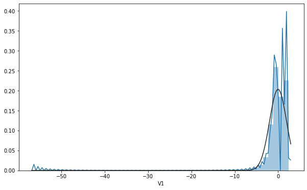

```python
# Y dibujamos la distribución
plt.figure(figsize= [10.0, 6.0])
sns.distplot(df["V1"], fit=norm)
```

En el gráfico vemos que una gran cantidad de los datos de `V1` se concentran en un pequeño tramo. Y una cantidad menor se distribuyen hasta alcanzar el mínimo que hemos visto en las estadísticas. Veamos ahora gráficamente la relación de esta variable con la variable `Class`.

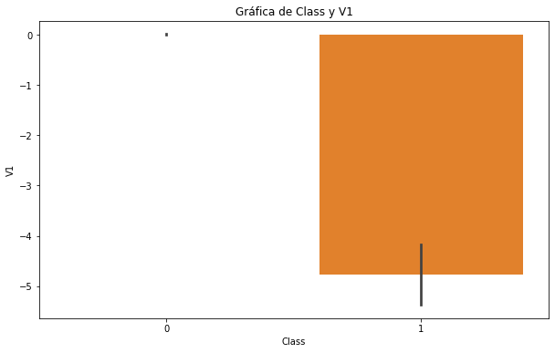

```python
# Dibujamos Class y V1
plt.figure(figsize= [10.0, 6.0])
plt.title("Gráfica de Class y V1")
sns.barplot(x="Class", y="V1", data= df)
plt.show()
```

La correlación es una métrica de análisis de datos para ver la relación entre diversas variables. Veamos la correlación entre `V1`y `Class`.

```python
# calculamos la correlación entre Class y V1
corr_mat = df.corr()
corr_mat.loc["Class", "V1"]
```

```
-0.10134729859508294
```

La correlación entre las variables Class y V1 es de -0.101 por lo que consideramos que no hay correlación entre ellas.

#### `V2`

Desconocemos el significado de esta variable debido a la sensibilidad de los datos bancarios.

```python
print("La siguiente variable que vamos a examinar es {0}.".format(df.columns[2]))
```

```
La siguiente variable que vamos a examinar es V2.
```

```python
# Visualizamos los primeros 10 elementos de 'V2'
df["V2"].head(10)
```

```
0   -0.072781
1    0.266151
2   -1.340163
3   -0.185226
4    0.877737
5    0.960523
6    0.141004
7    1.417964
8    0.286157
9    1.119593
Name: V2, dtype: float64
```

```python
# y los 10 últimos
df["V2"].tail(10)
```

```
284797     0.712247
284798     0.881246
284799    -0.004235
284800    -0.175233
284801     0.931005
284802    10.071785
284803    -0.055080
284804    -0.301254
284805     0.530483
284806    -0.189733
Name: V2, dtype: float64
```

```python
# Vemos el número total de observaciones de V2 y cuántos de esos valores son únicos
print("La variable {0} tiene un total de {1} observaciones y {2} valores únicos.".format(df.columns[2],
                                                                                         df["V2"].count(),
                                                                                         df["V2"].nunique()))
```

```
La variable V2 tiene un total de 284807 observaciones y 275663 valores únicos.
```

```python
# Vemos sus estadísticas
df["V2"].describe()
```

```
count    2.848070e+05
mean     5.682686e-16
std      1.651309e+00
min     -7.271573e+01
25%     -5.985499e-01
50%      6.548556e-02
75%      8.037239e-01
max      2.205773e+01
Name: V2, dtype: float64
```

```python
# Imprimimos en pantalla algunas de las estadísticas:
print("La variable `V2` tiene:\n un valor mínimo de {0},\
 \n un máximo de {1}, \n una media de {2} \n y una desviación típica de {3}.".format(round(df["V2"].min(),3),
                                                                                   round(df["V2"].max(),3),
                                                                                  round(df["V2"].mean(),3),
                                                                                  round(df["V2"].std(),3)))
```

```
La variable `V2` tiene:
 un valor mínimo de -72.716,
 un máximo de 22.058,
 una media de 0.0
 y una desviación típica de 1.651.
```

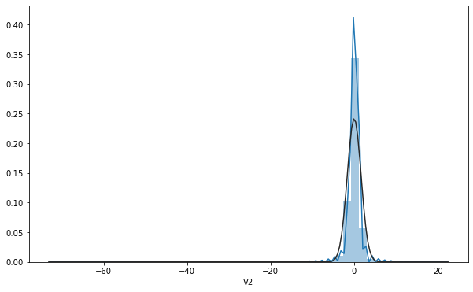

```python
# Dibujamos la distribución p
plt.figure(figsize= [10.0, 6.0])
sns.distplot(df["V2"], fit=norm)
```

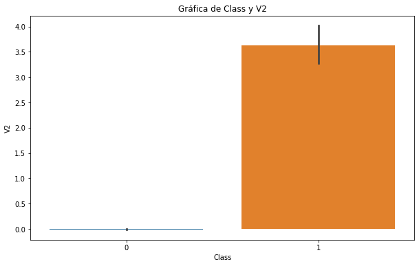

```python
# Dibujamos Class y V2
plt.figure(figsize= [10.0, 6.0])
plt.title("Gráfica de Class y V2")
sns.barplot(x="Class", y="V2", data= df)
plt.show()
```

```python
# calculamos la correlación entre Time y V2
corr_mat = df.corr()
corr_mat.loc["Class", "V2"]
```

```
0.0912886503446179
```

Como vemos tanto en el gráfico como en el coeficiente de correlación (0.091), las variables Class y V2 no están correlacionadas.

#### `V3`

Desconocemos el significado de esta variable debido a la sensibilidad de los datos bancarios.

```python
print("La siguiente variable que vamos a examinar es {0}.".format(df.columns[3]))
```

```
La siguiente variable que vamos a examinar es V3.
```

```python
# Visualizamos los primeros 10 elementos de 'V3'
df["V3"].head(10)
```

```
0    2.536347
1    0.166480
2    1.773209
3    1.792993
4    1.548718
5    1.141109
6    0.045371
7    1.074380
8   -0.113192
9    1.044367
Name: V3, dtype: float64
```

```python
# y los 10 últimos
df["V3"].tail(10)
```

```
284797    0.399806
284798   -0.635891
284799    1.189786
284800   -1.196825
284801   -0.546012
284802   -9.834783
284803    2.035030
284804   -3.249640
284805    0.702510
284806    0.703337
Name: V3, dtype: float64
```

```python
# Vemos el número total de observaciones de V3 y cuántos de esos valores son único
print("La variable {0} tiene un total de {1} observaciones y {2} valores únicos.".format(df.columns[3],
                                                                                         df["V3"].count(),
                                                                                         df["V3"].nunique()))
```

```
La variable V3 tiene un total de 284807 observaciones y 275663 valores únicos.
```

```python
# Vemos sus estadísticas
df["V3"].describe()
```

```
count    2.848070e+05
mean    -8.761736e-15
std      1.516255e+00
min     -4.832559e+01
25%     -8.903648e-01
50%      1.798463e-01
75%      1.027196e+00
max      9.382558e+00
Name: V3, dtype: float64
```

```python
# Imprimimos en pantalla algunas de las estadísticas:
print("La variable `V3` tiene:\n un valor mínimo de {0},\
 \n un máximo de {1}, \n una media de {2} \n y una desviación típica de {3}.".format(round(df["V3"].min(),3),
                                                                                   round(df["V3"].max(),3),
                                                                                  round(df["V3"].mean(),3),
                                                                                  round(df["V3"].std(),3)))
```

```
La variable `V3` tiene:
 un valor mínimo de -48.326,
 un máximo de 9.383,
 una media de -0.0
 y una desviación típica de 1.516.
```

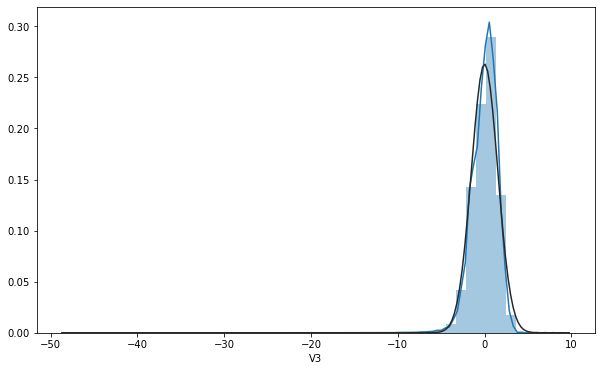

```python
# Dibujamos la distribución
plt.figure(figsize= [10.0, 6.0])
sns.distplot(df["V3"], fit=norm)
```

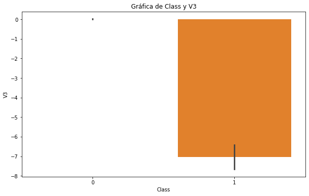

```python
# Dibujamos Class y V3
plt.figure(figsize= [10.0, 6.0])
plt.title("Gráfica de Class y V3")
sns.barplot(x="Class", y="V3", data= df)
plt.show()
```

```python
# calculamos la correlación entre Class y V3
corr_mat = df.corr()
corr_mat.loc["Class", "V3"]
```

```
-0.19296082706741602
```

#### `V4`

Desconocemos el significado de esta variable debido a la sensibilidad de los datos bancarios.

```python
print("La siguiente variable que vamos a examinar es {0}.".format(df.columns[4]))
```

```
La siguiente variable que vamos a examinar es V4.
```

```python
# Visualizamos los primeros 10 elementos de 'V4'
df["V4"].head(10)
```

```
0    1.378155
1    0.448154
2    0.379780
3   -0.863291
4    0.403034
5   -0.168252
6    1.202613
7   -0.492199
8   -0.271526
9   -0.222187
Name: V4, dtype: float64
```

```python
# y los 10 últimos
df["V4"].tail(10)
```

```
284797   -0.463406
284798    0.960928
284799    0.331096
284800    0.234580
284801   -0.745097
284802   -2.066656
284803   -0.738589
284804   -0.557828
284805    0.689799
284806   -0.506271
Name: V4, dtype: float64
```

```python
# Vemos el número total de observaciones de V4 y cuántos de esos valores son únicos
print("La variable {0} tiene un total de {1} observaciones y {2} valores únicos.".format(df.columns[4],
                                                                                         df["V4"].count(),
                                                                                         df["V4"].nunique()))
```

```
La variable V4 tiene un total de 284807 observaciones y 275663 valores únicos.
```

```python
# Vemos las estadísticas de V4
df["V4"].describe()
```

```
count    2.848070e+05
mean     2.811118e-15
std      1.415869e+00
min     -5.683171e+00
25%     -8.486401e-01
50%     -1.984653e-02
75%      7.433413e-01
max      1.687534e+01
Name: V4, dtype: float64
```

```python
# Imprimimos en pantalla algunas de las estadísticas:
print("La variable `V4` tiene:\n un valor mínimo de {0},\
 \n un máximo de {1}, \n una media de {2} \n y una desviación típica de {3}.".format(round(df["V4"].min(),3),
                                                                                   round(df["V4"].max(),3),
                                                                                  round(df["V4"].mean(),3),
                                                                                  round(df["V4"].std(),3)))
```

```
La variable `V4` tiene:
 un valor mínimo de -5.683,
 un máximo de 16.875,
 una media de 0.0
 y una desviación típica de 1.416.
```

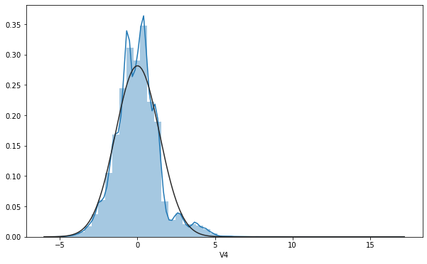

```python
# Dibujamos la distribución
plt.figure(figsize= [10.0, 6.0])
sns.distplot(df["V4"], fit=norm)
```

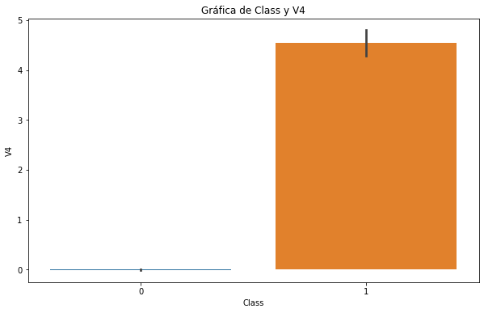

```python
# Dibujamos Class y V4
plt.figure(figsize= [10.0, 6.0])
plt.title("Gráfica de Class y V4")
sns.barplot(x="Class", y="V4", data= df)
plt.show()
```

```python
# calculamos la correlación entre Class y V4
corr_mat = df.corr()
corr_mat.loc["Class", "V4"]
```

```
0.13344748623900718
```

#### `V5`

Desconocemos el significado de esta variable debido a la sensibilidad de los datos bancarios.

```python
print("La siguiente variable que vamos a examinar es {0}.".format(df.columns[5]))
```

```
La siguiente variable que vamos a examinar es V5.
```

```python
# Visualizamos los primeros 10 elementos de 'V5'
df["V5"].head(10)
```

```
0   -0.338321
1    0.060018
2   -0.503198
3   -0.010309
4   -0.407193
5    0.420987
6    0.191881
7    0.948934
8    2.669599
9    0.499361
Name: V5, dtype: float64
```

```python
# así como los 10 últimos
df["V5"].tail(10)
```

```
284797    0.244531
284798   -0.152971
284799    1.196063
284800   -0.008713
284801    1.130314
284802   -5.364473
284803    0.868229
284804    2.630515
284805   -0.377961
284806   -0.012546
Name: V5, dtype: float64
```

```python
# Vemos el número total de observaciones de V5 y cuántos de esos valores son únicos
print("La variable {0} tiene un total de {1} observaciones y {2} valores únicos.".format(df.columns[5],
                                                                                         df["V5"].count(),
                                                                                         df["V5"].nunique()))
```

```
La variable V5 tiene un total de 284807 observaciones y 275663 valores únicos.
```

```python
# Vemos las estadísticas de V5
df["V5"].describe()
```

```
count    2.848070e+05
mean    -1.552103e-15
std      1.380247e+00
min     -1.137433e+02
25%     -6.915971e-01
50%     -5.433583e-02
75%      6.119264e-01
max      3.480167e+01
Name: V5, dtype: float64
```

```python
# Imprimimos en pantalla algunas de las estadísticas:
print("La variable `V5` tiene:\n un valor mínimo de {0},\
 \n un máximo de {1}, \n una media de {2} \n y una desviación típica de {3}.".format(round(df["V5"].min(),3),
                                                                                   round(df["V5"].max(),3),
                                                                                  round(df["V5"].mean(),3),
                                                                                  round(df["V5"].std(),3)))
```

```
La variable `V5` tiene:
 un valor mínimo de -113.743,
 un máximo de 34.802,
 una media de -0.0
 y una desviación típica de 1.38.
```

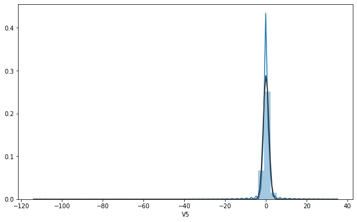

```python
# Dibujamos la distribución
plt.figure(figsize= [10.0, 6.0])
sns.distplot(df["V5"], fit=norm)
```

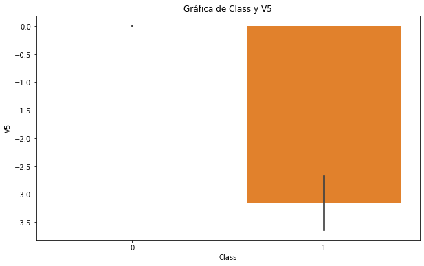

```python
# Dibujamos Class y V5
plt.figure(figsize= [10.0, 6.0])
plt.title("Gráfica de Class y V5")
sns.barplot(x="Class", y="V5", data= df)
plt.show()
```

```python
# calculamos la correlación entre Class y V5
corr_mat = df.corr()
corr_mat.loc["Class", "V5"]
```

```
-0.09497429899144802
```

#### `V6`

Desconocemos el significado de esta variable debido a la sensibilidad de los datos bancarios.

```python
print("La siguiente variable que vamos a examinar es {0}.".format(df.columns[6]))
```

```
La siguiente variable que vamos a examinar es V6.
```

```python
# Visualizamos los primeros 10 elementos de 'V6'
df["V6"].head(10)
```

```
0    0.462388
1   -0.082361
2    1.800499
3    1.247203
4    0.095921
5   -0.029728
6    0.272708
7    0.428118
8    3.721818
9   -0.246761
Name: V6, dtype: float64
```

```python
# así como los 10 últimos
df["V6"].tail(10)
```

```
284797   -1.343668
284798   -1.014307
284799    5.519980
284800   -0.726571
284801   -0.235973
284802   -2.606837
284803    1.058415
284804    3.031260
284805    0.623708
284806   -0.649617
Name: V6, dtype: float64
```

```python
# Vemos el número total de observaciones de V6 y cuántos de esos valores son únicos
print("La variable {0} tiene un total de {1} observaciones y {2} valores únicos.".format(df.columns[6],
                                                                                         df["V6"].count(),
                                                                                         df["V6"].nunique()))
```

```
La variable V6 tiene un total de 284807 observaciones y 275663 valores únicos.
```

```python
# Vemos las estadísticas de V6
df["V6"].describe()
```

```
count    2.848070e+05
mean     2.040130e-15
std      1.332271e+00
min     -2.616051e+01
25%     -7.682956e-01
50%     -2.741871e-01
75%      3.985649e-01
max      7.330163e+01
Name: V6, dtype: float64
```

```python
# Imprimimos en pantalla algunas de las estadísticas:
print("La variable `V6` tiene:\n un valor mínimo de {0},\
 \n un máximo de {1}, \n una media de {2} \n y una desviación típica de {3}.".format(round(df["V6"].min(),3),
                                                                                   round(df["V6"].max(),3),
                                                                                  round(df["V6"].mean(),3),
                                                                                  round(df["V6"].std(),3)))
```

```
La variable `V6` tiene:
 un valor mínimo de -26.161,
 un máximo de 73.302,
 una media de 0.0
 y una desviación típica de 1.332.
```

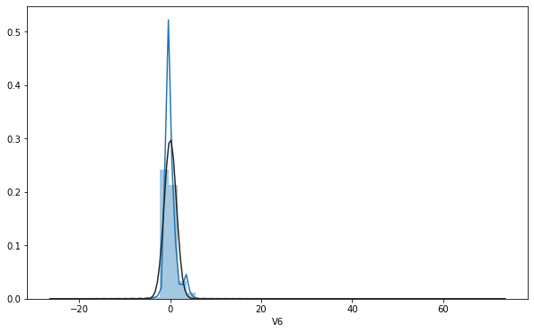

```python
# Dibujamos la distribución
plt.figure(figsize= [10.0, 6.0])
sns.distplot(df["V6"], fit=norm)
```

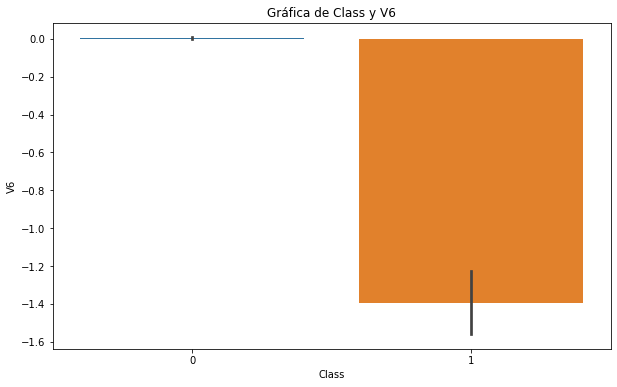

```python
# Dibujamos Class y V6
plt.figure(figsize= [10.0, 6.0])
plt.title("Gráfica de Class y V6")
sns.barplot(x="Class", y="V6", data= df)
plt.show()
```

```python
# calculamos la correlación entre Class y V6
corr_mat = df.corr()
corr_mat.loc["Class", "V6"]
```

```
-0.04364316069996494
```

#### `V7`

Desconocemos el significado de esta variable debido a la sensibilidad de los datos bancarios.

```python
print("La siguiente variable que vamos a examinar es {0}.".format(df.columns[7]))
```

```
La siguiente variable que vamos a examinar es V7.
```

```python
# Visualizamos los primeros 10 elementos de 'V7'
df["V7"].head(10)
```

```
0    0.239599
1   -0.078803
2    0.791461
3    0.237609
4    0.592941
5    0.476201
6   -0.005159
7    1.120631
8    0.370145
9    0.651583
Name: V7, dtype: float64
```

```python
# así como los 10 últimos
df["V7"].tail(10)
```

```
284797    0.929369
284798    0.427126
284799   -1.518185
284800    0.017050
284801    0.812722
284802   -4.918215
284803    0.024330
284804   -0.296827
284805   -0.686180
284806    1.577006
Name: V7, dtype: float64
```

```python
# Vemos el número total de observaciones de V7 y cuántos de esos valores son únicos
print("La variable {0} tiene un total de {1} observaciones y {2} valores únicos.".format(df.columns[7],
                                                                                         df["V7"].count(),
                                                                                         df["V7"].nunique()))
```

```
La variable V7 tiene un total de 284807 observaciones y 275663 valores únicos.
```

```python
# Vemos las estadísticas de V7
df["V7"].describe()
```

```
count    2.848070e+05
mean    -1.698953e-15
std      1.237094e+00
min     -4.355724e+01
25%     -5.540759e-01
50%      4.010308e-02
75%      5.704361e-01
max      1.205895e+02
Name: V7, dtype: float64
```

```python
# Imprimimos en pantalla algunas de las estadísticas:
print("La variable `V7` tiene:\n un valor mínimo de {0},\
 \n un máximo de {1}, \n una media de {2} \n y una desviación típica de {3}.".format(round(df["V7"].min(),3),
                                                                                   round(df["V7"].max(),3),
                                                                                  round(df["V7"].mean(),3),
                                                                                  round(df["V7"].std(),3)))
```

```
La variable `V7` tiene:
 un valor mínimo de -43.557,
 un máximo de 120.589,
 una media de -0.0
 y una desviación típica de 1.237.
```

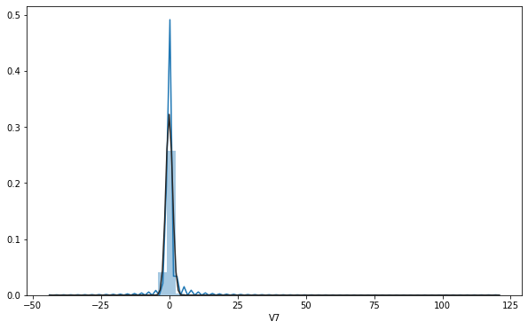

```python
# Dibujamos la distribución
plt.figure(figsize= [10.0, 6.0])
sns.distplot(df["V7"], fit=norm)
```

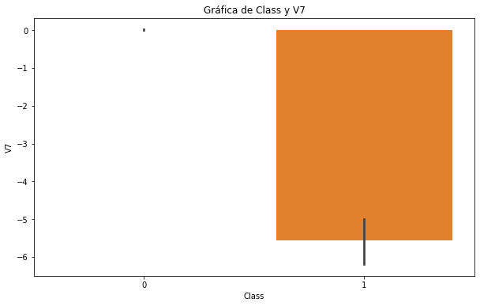

```python
# Dibujamos Class y V7
plt.figure(figsize= [10.0, 6.0])
plt.title("Gráfica de Class y V7")
sns.barplot(x="Class", y="V7", data= df)
plt.show()
```

```python
# calculamos la correlación entre Class y V7
corr_mat = df.corr()
corr_mat.loc["Class", "V7"]
```

```
-0.18725659151430013
```

#### `V8`

Desconocemos el significado de esta variable debido a la sensibilidad de los datos bancarios.

```python
print("La siguiente variable que vamos a examinar es {0}.".format(df.columns[8]))
```

```
La siguiente variable que vamos a examinar es V8.
```

```python
# Visualizamos los primeros 10 elementos de 'V8'
df["V8"].head(10)
```

```
0    0.098698
1    0.085102
2    0.247676
3    0.377436
4   -0.270533
5    0.260314
6    0.081213
7   -3.807864
8    0.851084
9    0.069539
Name: V8, dtype: float64
```

```python
# y los 10 últimos:
df["V8"].tail(10)
```

```
284797   -0.206210
284798    0.121340
284799    2.080825
284800   -0.118228
284801    0.115093
284802    7.305334
284803    0.294869
284804    0.708417
284805    0.679145
284806   -0.414650
Name: V8, dtype: float64
```

```python
# Vemos el número total de observaciones de V8 y cuántos de esos valores son únicos
print("La variable {0} tiene un total de {1} observaciones y {2} valores únicos.".format(df.columns[8],
                                                                                         df["V8"].count(),
                                                                                         df["V8"].nunique()))
```

```
La variable V8 tiene un total de 284807 observaciones y 275663 valores únicos.
```

```python
# Vemos las estadísticas de V8
df["V8"].describe()
```

```
count    2.848070e+05
mean    -1.893285e-16
std      1.194353e+00
min     -7.321672e+01
25%     -2.086297e-01
50%      2.235804e-02
75%      3.273459e-01
max      2.000721e+01
Name: V8, dtype: float64
```

```python
# Imprimimos en pantalla algunas de las estadísticas:
print("La variable `V8` tiene:\n un valor mínimo de {0},\
 \n un máximo de {1}, \n una media de {2} \n y una desviación típica de {3}.".format(round(df["V8"].min(),3),
                                                                                   round(df["V8"].max(),3),
                                                                                  round(df["V8"].mean(),3),
                                                                                  round(df["V8"].std(),3)))
```

```
La variable `V8` tiene:
 un valor mínimo de -73.217,
 un máximo de 20.007,
 una media de -0.0
 y una desviación típica de 1.194.
```

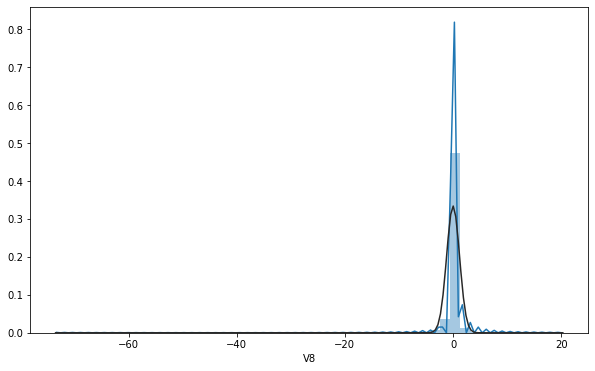

```python
# Dibujamos la distribución
plt.figure(figsize= [10.0, 6.0])
sns.distplot(df["V8"], fit=norm)
```

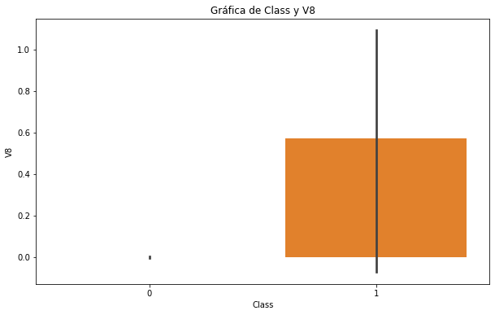

```python
# Dibujamos Class y V8
plt.figure(figsize= [10.0, 6.0])
plt.title("Gráfica de Class y V8")
sns.barplot(x="Class", y="V8", data= df)
plt.show()
```

```python
# calculamos la correlación entre Class y V8
corr_mat = df.corr()
corr_mat.loc["Class", "V8"]
```

```
0.019875123914794384
```

`V9`

Por la sensibilidad de los datos bancarios, desconocemos el valor de esta variable.

```python
print("La siguiente variable que vamos a examinar es {0}.".format(df.columns[9]))
```

```
La siguiente variable que vamos a examinar es V9.
```

```python
# Visualizamos los primeros 10 elementos de 'V9'
df["V9"].head(10)
```

```
0    0.363787
1   -0.255425
2   -1.514654
3   -1.387024
4    0.817739
5   -0.568671
6    0.464960
7    0.615375
8   -0.392048
9   -0.736727
Name: V9, dtype: float64
```

```python
# y los 10 últimos:
df["V9"].tail(10)
```

```
284797    0.106234
284798   -0.285670
284799    1.159498
284800    0.435402
284801   -0.204064
284802    1.914428
284803    0.584800
284804    0.432454
284805    0.392087
284806    0.486180
Name: V9, dtype: float64
```

```python
# Vemos el número total de observaciones de V9 y cuántos de esos valores son únicos
print("La variable {0} tiene un total de {1} observaciones y {2} valores únicos.".format(df.columns[9],
                                                                                         df["V9"].count(),
                                                                                         df["V9"].nunique()))
```

```
La variable V9 tiene un total de 284807 observaciones y 275663 valores únicos.
```

```python
# Vemos las estadísticas de V9
df["V9"].describe()
```

```
count    2.848070e+05
mean    -3.147640e-15
std      1.098632e+00
min     -1.343407e+01
25%     -6.430976e-01
50%     -5.142873e-02
75%      5.971390e-01
max      1.559499e+01
Name: V9, dtype: float64
```

```python
# Imprimimos en pantalla algunas de las estadísticas:
print("La variable `V9` tiene:\n un valor mínimo de {0},\
 \n un máximo de {1}, \n una media de {2} \n y una desviación típica de {3}.".format(round(df["V9"].min(),3),
                                                                                   round(df["V9"].max(),3),
                                                                                  round(df["V9"].mean(),3),
                                                                                  round(df["V9"].std(),3)))
```

```
La variable `V9` tiene:
 un valor mínimo de -13.434,
 un máximo de 15.595,
 una media de -0.0
 y una desviación típica de 1.099.
```

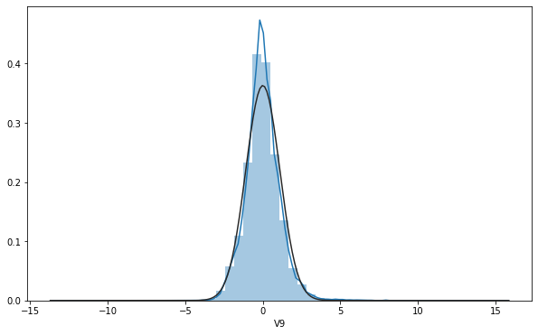

```python
# Dibujamos la distribución
plt.figure(figsize= [10.0, 6.0])
sns.distplot(df["V9"], fit=norm)
```

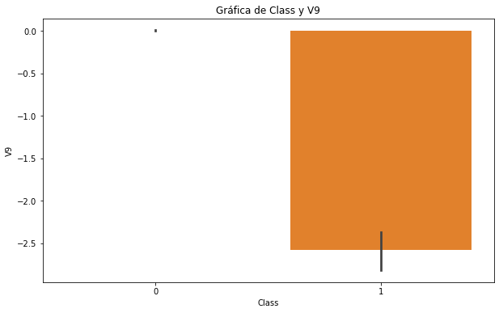

```python
# Dibujamos Class y V9
plt.figure(figsize= [10.0, 6.0])
plt.title("Gráfica de Class y V9")
sns.barplot(x="Class", y="V9", data= df)
plt.show()
```

```python
# calculamos la correlación entre Class y V9
corr_mat = df.corr()
corr_mat.loc["Class", "V9"]
```

```
-0.0977326860740807
```

`V10`

Debido a la sensibilidad de los datos que manejamos, desconocemos el significado de esta variable.

```python
print("La siguiente variable que vamos a examinar es {0}.".format(df.columns[10]))
```

```
La siguiente variable que vamos a examinar es V10.
```

```python
# Visualizamos los 10 primeros elementos de `V10`
df["V10"].head(10)
```

```
0    0.090794
1   -0.166974
2    0.207643
3   -0.054952
4    0.753074
5   -0.371407
6   -0.099254
7    1.249376
8   -0.410430
9   -0.366846
Name: V10, dtype: float64
```

```python
# y también los 10 últimos
df["V10"].tail(10)
```

```
284797   -0.284708
284798   -0.111640
284799   -0.594242
284800    0.267772
284801   -0.657422
284802    4.356170
284803   -0.975926
284804   -0.484782
284805   -0.399126
284806   -0.915427
Name: V10, dtype: float64
```

```python
# Vemos el número total de observaciones de V10 y cuántos de esos valores son únicos
print("La variable {0} tiene un total de {1} observaciones y {2} valores únicos.".format(df.columns[10],
                                                                                         df["V10"].count(),
                                                                                         df["V10"].nunique()))
```

```
La variable V10 tiene un total de 284807 observaciones y 275663 valores únicos.
```

```python
# Vemos sus estadísticas
df["V10"].describe()
```

```
count    2.848070e+05
mean     1.772925e-15
std      1.088850e+00
min     -2.458826e+01
25%     -5.354257e-01
50%     -9.291738e-02
75%      4.539234e-01
max      2.374514e+01
Name: V10, dtype: float64
```

```python
# Imprimimos en pantalla algunas de las estadísticas:
print("La variable `V10` tiene:\n un valor mínimo de {0},\
 \n un máximo de {1}, \n una media de {2} \n y una desviación típica de {3}.".format(round(df["V10"].min(),3),
                                                                                   round(df["V10"].max(),3),
                                                                                  round(df["V10"].mean(),3),
                                                                                  round(df["V10"].std(),3)))
```

```
La variable `V10` tiene:
 un valor mínimo de -24.588,
 un máximo de 23.745,
 una media de 0.0
 y una desviación típica de 1.089.
```

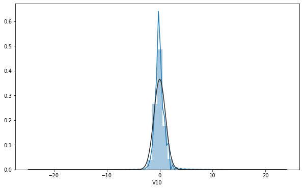

```python
# Y dibujamos la distribución
plt.figure(figsize= [10.0, 6.0])
sns.distplot(df["V10"], fit=norm)
```

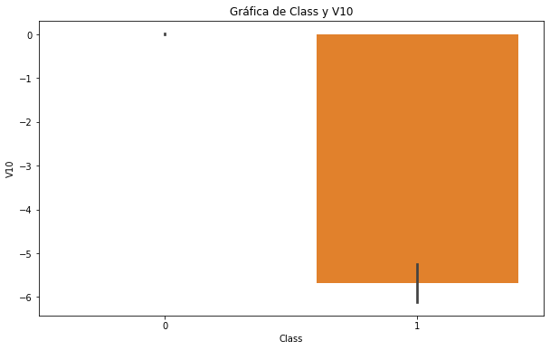

```python
# Dibujamos Class y V10
plt.figure(figsize= [10.0, 6.0])
plt.title("Gráfica de Class y V10")
sns.barplot(x="Class", y="V10", data= df)
plt.show()
```

```python
# calculamos la correlación entre Class y V10
corr_mat = df.corr()
corr_mat.loc["Class", "V10"]
```

```
-0.21688294364103206
```

`V11`

Debido a la sensibilidad de los datos que manejamos, desconocemos el significado de esta variable.

```python
print("La siguiente variable que vamos a examinar es {0}.".format(df.columns[11]))
```

```
La siguiente variable que vamos a examinar es V11.
```

```python
# Visualizamos los primeros 10 elementos de 'V11'
df["V11"].head(10)
```

```
0   -0.551600
1    1.612727
2    0.624501
3   -0.226487
4   -0.822843
5    1.341262
6   -1.416907
7   -0.619468
8   -0.705117
9    1.017614
Name: V11, dtype: float64
```

```python
# y los 10 últimos:
df["V11"].tail(10)
```

```
284797   -0.612982
284798   -1.109232
284799   -1.264072
284800    0.523316
284801    0.644837
284802   -1.593105
284803   -0.150189
284804    0.411614
284805   -1.933849
284806   -1.040458
Name: V11, dtype: float64
```

```python
# Vemos el número total de observaciones de V11 y cuántos de esos valores son únicos
print("La variable {0} tiene un total de {1} observaciones y {2} valores únicos.".format(df.columns[11],
                                                                                         df["V11"].count(),
                                                                                         df["V11"].nunique()))
```

```
La variable V11 tiene un total de 284807 observaciones y 275663 valores únicos.
```

```python
# Vemos las estadísticas de V11
df["V11"].describe()
```

```
count    2.848070e+05
mean     9.289524e-16
std      1.020713e+00
min     -4.797473e+00
25%     -7.624942e-01
50%     -3.275735e-02
75%      7.395934e-01
max      1.201891e+01
Name: V11, dtype: float64
```

```python
# Imprimimos en pantalla algunas de las estadísticas:
print("La variable `V11` tiene:\n un valor mínimo de {0},\
 \n un máximo de {1}, \n una media de {2} \n y una desviación típica de {3}.".format(round(df["V11"].min(),3),
                                                                                   round(df["V11"].max(),3),
                                                                                  round(df["V11"].mean(),3),
                                                                                  round(df["V11"].std(),3)))
```

```
La variable `V11` tiene:
 un valor mínimo de -4.797,
 un máximo de 12.019,
 una media de 0.0
 y una desviación típica de 1.021.
```

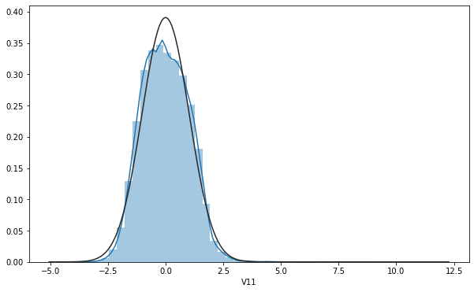

```python
# Dibujamos la distribución
plt.figure(figsize= [10.0, 6.0])
sns.distplot(df["V11"], fit=norm)
```

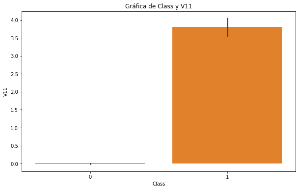

```python
# Dibujamos Class y V11
plt.figure(figsize= [10.0, 6.0])
plt.title("Gráfica de Class y V11")
sns.barplot(x="Class", y="V11", data= df)
plt.show()
```

```python
# calculamos la correlación entre Class y V11
corr_mat = df.corr()
corr_mat.loc["Class", "V11"]
```

```
0.15487564474394433
```

`V12`

Debido a la sensibilidad de los datos que manejamos, desconocemos el significado de esta variable.

```python
print("La siguiente variable que vamos a examinar es {0}.".format(df.columns[12]))
```

```
La siguiente variable que vamos a examinar es V12.
```

```python
# Visualizamos los primeros 10 elementos de 'V12'
df["V12"].head(10)
```

```
0   -0.617801
1    1.065235
2    0.066084
3    0.178228
4    0.538196
5    0.359894
6   -0.153826
7    0.291474
8   -0.110452
9    0.836390
Name: V12, dtype: float64
```

```python
# y los 10 últimos:
df["V12"].tail(10)
```

```
284797   -0.066655
284798   -0.453235
284799    0.453596
284800    0.559047
284801    0.190916
284802    2.711941
284803    0.915802
284804    0.063119
284805   -0.962886
284806   -0.031513
Name: V12, dtype: float64
```

```python
# Vemos el número total de observaciones de V12 y cuántos de esos valores son únicos
print("La variable {0} tiene un total de {1} observaciones y {2} valores únicos.".format(df.columns[12],
                                                                                         df["V12"].count(),
                                                                                         df["V12"].nunique()))
```

```
La variable V12 tiene un total de 284807 observaciones y 275663 valores únicos.
```

```python
# Vemos las estadísticas de V12
df["V12"].describe()
```

```
count    2.848070e+05
mean    -1.803266e-15
std      9.992014e-01
min     -1.868371e+01
25%     -4.055715e-01
50%      1.400326e-01
75%      6.182380e-01
max      7.848392e+00
Name: V12, dtype: float64
```

```python
# Imprimimos en pantalla algunas de las estadísticas:
print("La variable `V12` tiene:\n un valor mínimo de {0},\
 \n un máximo de {1}, \n una media de {2} \n y una desviación típica de {3}.".format(round(df["V12"].min(),3),
                                                                                   round(df["V12"].max(),3),
                                                                                  round(df["V12"].mean(),3),
                                                                                  round(df["V12"].std(),3)))
```

```
La variable `V12` tiene:
 un valor mínimo de -18.684,
 un máximo de 7.848,
 una media de -0.0
 y una desviación típica de 0.999.
```

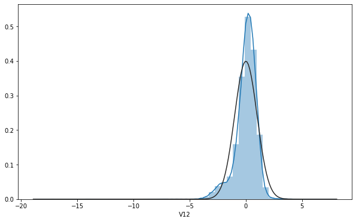

```python
# Dibujamos la distribución
plt.figure(figsize= [10.0, 6.0])
sns.distplot(df["V12"], fit=norm)
```

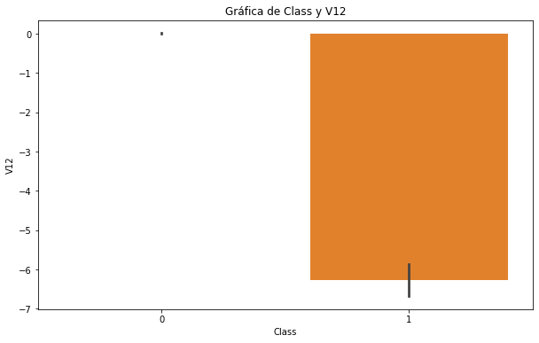

```python
# Dibujamos Class y V12
plt.figure(figsize= [10.0, 6.0])
plt.title("Gráfica de Class y V12")
sns.barplot(x="Class", y="V12", data= df)
plt.show()
```

```python
# calculamos la correlación entre Class y V12
corr_mat = df.corr()
corr_mat.loc["Class", "V12"]
```

```
-0.26059292487722485
```

`V13`

Debido a la sensibilidad de los datos que manejamos, desconocemos el significado de esta variable.

```python
print("La siguiente variable que vamos a examinar es {0}.".format(df.columns[13]))
```

```
La siguiente variable que vamos a examinar es V13.
```

```python
# Visualizamos los primeros 10 elementos de 'V13'
df["V13"].head(10)
```

```
0   -0.991390
1    0.489095
2    0.717293
3    0.507757
4    1.345852
5   -0.358091
6   -0.751063
7    1.757964
8   -0.286254
9    1.006844
Name: V13, dtype: float64
```

```python
# y los 10 últimos:
df["V13"].tail(10)
```

```
284797   -0.732987
284798   -1.046946
284799   -0.243142
284800   -0.834660
284801   -0.546329
284802   -0.689256
284803    1.214756
284804   -0.183699
284805   -1.042082
284806   -0.188093
Name: V13, dtype: float64
```

```python
# Vemos el número total de observaciones de V13 y cuántos de esos valores son únicos
print("La variable {0} tiene un total de {1} observaciones y {2} valores únicos.".format(df.columns[13],
                                                                                         df["V13"].count(),
                                                                                         df["V13"].nunique()))
```

```
La variable V13 tiene un total de 284807 observaciones y 275663 valores únicos.
```

```python
# Vemos las estadísticas de V13
df["V13"].describe()
```

```
count    2.848070e+05
mean     1.674888e-15
std      9.952742e-01
min     -5.791881e+00
25%     -6.485393e-01
50%     -1.356806e-02
75%      6.625050e-01
max      7.126883e+00
Name: V13, dtype: float64
```

```python
# Imprimimos en pantalla algunas de las estadísticas:
print("La variable `V13` tiene:\n un valor mínimo de {0},\
 \n un máximo de {1}, \n una media de {2} \n y una desviación típica de {3}.".format(round(df["V13"].min(),3),
                                                                                   round(df["V13"].max(),3),
                                                                                  round(df["V13"].mean(),3),
                                                                                  round(df["V13"].std(),3)))
```

```
La variable `V13` tiene:
 un valor mínimo de -5.792,
 un máximo de 7.127,
 una media de 0.0
 y una desviación típica de 0.995.
```

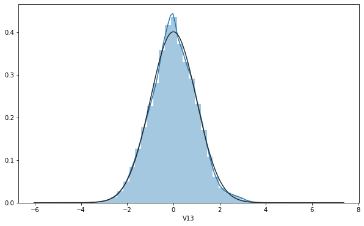

```python
# Dibujamos la distribución
plt.figure(figsize= [10.0, 6.0])
sns.distplot(df["V13"], fit=norm)
```

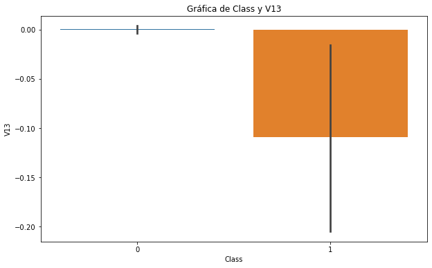

```python
# Dibujamos Class y V13
plt.figure(figsize= [10.0, 6.0])
plt.title("Gráfica de Class y V13")
sns.barplot(x="Class", y="V13", data= df)
plt.show()
```

```python
# calculamos la correlación entre Class y V13
corr_mat = df.corr()
corr_mat.loc["Class", "V13"]
```

```
-0.004569778799461309
```

`V14`

Debido a la sensibilidad de los datos que manejamos, desconocemos el significado de esta variable.

```python
print("La siguiente variable que vamos a examinar es {0}.".format(df.columns[14]))
```

```
La siguiente variable que vamos a examinar es V14.
```

```python
# Visualizamos los primeros 10 elementos de 'V14'
df["V14"].head(10)
```

```
0   -0.311169
1   -0.143772
2   -0.165946
3   -0.287924
4   -1.119670
5   -0.137134
6    0.167372
7   -1.323865
8    0.074355
9   -0.443523
Name: V14, dtype: float64
```

```python
# y los 10 últimos:
df["V14"].tail(10)
```

```
284797    0.237948
284798    1.122674
284799   -0.858719
284800    0.626211
284801   -0.731707
284802    4.626942
284803   -0.675143
284804   -0.510602
284805    0.449624
284806   -0.084316
Name: V14, dtype: float64
```

```python
# Vemos el número total de observaciones de V14 y cuántos de esos valores son únicos
print("La variable {0} tiene un total de {1} observaciones y {2} valores únicos.".format(df.columns[14],
                                                                                         df["V14"].count(),
                                                                                         df["V14"].nunique()))
```

```
La variable V14 tiene un total de 284807 observaciones y 275663 valores únicos.
```

```python
# Vemos las estadísticas de V14
df["V14"].describe()
```

```
count    2.848070e+05
mean     1.475621e-15
std      9.585956e-01
min     -1.921433e+01
25%     -4.255740e-01
50%      5.060132e-02
75%      4.931498e-01
max      1.052677e+01
Name: V14, dtype: float64
```

```python
# Imprimimos en pantalla algunas de las estadísticas:
print("La variable `V14` tiene:\n un valor mínimo de {0},\
 \n un máximo de {1}, \n una media de {2} \n y una desviación típica de {3}.".format(round(df["V14"].min(),3),
                                                                                   round(df["V14"].max(),3),
                                                                                  round(df["V14"].mean(),3),
                                                                                  round(df["V14"].std(),3)))
```

```
La variable `V14` tiene:
 un valor mínimo de -19.214,
 un máximo de 10.527,
 una media de 0.0
 y una desviación típica de 0.959.
```

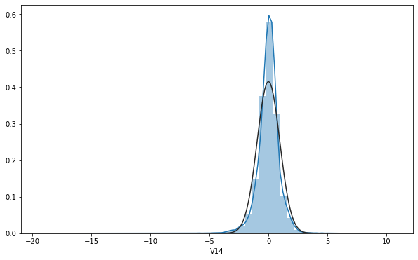

```python
# Dibujamos la distribución
plt.figure(figsize= [10.0, 6.0])
sns.distplot(df["V14"], fit=norm)
```

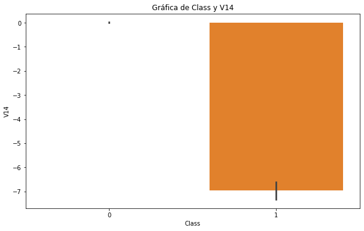

```python
# Dibujamos Class y V14
plt.figure(figsize= [10.0, 6.0])
plt.title("Gráfica de Class y V14")
sns.barplot(x="Class", y="V14", data= df)
plt.show()
```

```python
# calculamos la correlación entre Class y V14
corr_mat = df.corr()
corr_mat.loc["Class", "V14"]
```

```
-0.3025436958044028
```

En este caso vemos que la correlación entre Class y V14 es superior a las correlaciones con las variables anteriores.

`V15`

Desconocemos el valor de esta variable por la sensibilidad de los datos bancarios.

```python
print("La siguiente variable que vamos a examinar es {0}.".format(df.columns[15]))
```

```
La siguiente variable que vamos a examinar es V15.
```

```python
# Visualizamos los primeros 10 elementos de 'V15'
df["V15"].head(10)
```

```
0    1.468177
1    0.635558
2    2.345865
3   -0.631418
4    0.175121
5    0.517617
6    0.050144
7    0.686133
8   -0.328783
9    0.150219
Name: V15, dtype: float64
```

```python
# y los 10 últimos:
df["V15"].tail(10)
```

```
284797   -0.293959
284798    1.243518
284799   -0.766554
284800   -0.541494
284801   -0.808036
284802   -0.924459
284803    1.164931
284804    1.329284
284805    1.962563
284806    0.041333
Name: V15, dtype: float64
```

```python
# Vemos el número total de observaciones de V15 y cuántos de esos valores son únicos
print("La variable {0} tiene un total de {1} observaciones y {2} valores únicos.".format(df.columns[15],
                                                                                         df["V15"].count(),
                                                                                         df["V15"].nunique()))
```

```
La variable V15 tiene un total de 284807 observaciones y 275663 valores únicos.
```

```python
# Vemos las estadísticas de V15
df["V15"].describe()
```

```
count    2.848070e+05
mean     3.501098e-15
std      9.153160e-01
min     -4.498945e+00
25%     -5.828843e-01
50%      4.807155e-02
75%      6.488208e-01
max      8.877742e+00
Name: V15, dtype: float64
```

```python
# Imprimimos en pantalla algunas de las estadísticas:
print("La variable `V15` tiene:\n un valor mínimo de {0},\
 \n un máximo de {1}, \n una media de {2} \n y una desviación típica de {3}.".format(round(df["V15"].min(),3),
                                                                                   round(df["V15"].max(),3),
                                                                                  round(df["V15"].mean(),3),
                                                                                  round(df["V15"].std(),3)))
```

```
La variable `V15` tiene:
 un valor mínimo de -4.499,
 un máximo de 8.878,
 una media de 0.0
 y una desviación típica de 0.915.
```

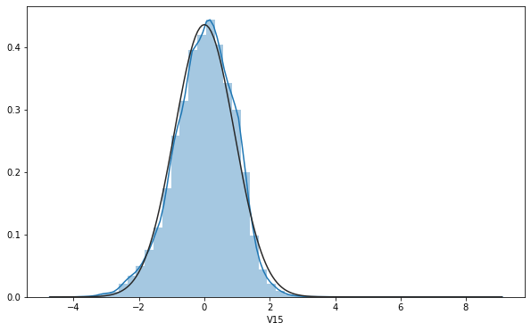

```python
# Dibujamos la distribución
plt.figure(figsize= [10.0, 6.0])
sns.distplot(df["V15"], fit=norm)
```

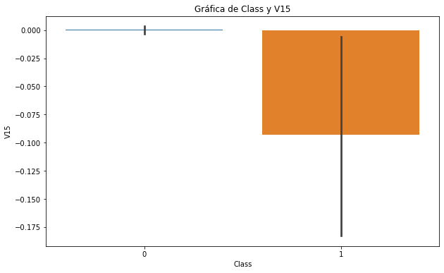

```python
# Dibujamos Class y V15
plt.figure(figsize= [10.0, 6.0])
plt.title("Gráfica de Class y V15")
sns.barplot(x="Class", y="V15", data= df)
plt.show()
```

```python
# calculamos la correlación entre Class y V15
corr_mat = df.corr()
corr_mat.loc["Class", "V15"]
```

```
-0.004223402267856675
```

`V16`

Desconocemos el valor de esta variable por la sensibilidad de los datos bancarios.

```python
print("La siguiente variable que vamos a examinar es {0}.".format(df.columns[16]))
```

```
La siguiente variable que vamos a examinar es V16.
```

```python
# Visualizamos los primeros 10 elementos de 'V16'
df["V16"].head(10)
```

```
0   -0.470401
1    0.463917
2   -2.890083
3   -1.059647
4   -0.451449
5    0.401726
6   -0.443587
7   -0.076127
8   -0.210077
9    0.739453
Name: V16, dtype: float64
```

```python
# y los 10 últimos:
df["V16"].tail(10)
```

```
284797   -0.245496
284798   -1.431897
284799   -0.644646
284800    0.225361
284801    0.599628
284802    1.107641
284803   -0.711757
284804    0.140716
284805   -0.608577
284806   -0.302620
Name: V16, dtype: float64
```

```python
# Vemos el número total de observaciones de V16 y cuántos de esos valores son únicos
print("La variable {0} tiene un total de {1} observaciones y {2} valores únicos.".format(df.columns[16],
                                                                                         df["V16"].count(),
                                                                                         df["V16"].nunique()))
```

```
La variable V16 tiene un total de 284807 observaciones y 275663 valores únicos.
```

```python
# Vemos las estadísticas de V16
df["V16"].describe()
```

```
count    2.848070e+05
mean     1.392460e-15
std      8.762529e-01
min     -1.412985e+01
25%     -4.680368e-01
50%      6.641332e-02
75%      5.232963e-01
max      1.731511e+01
Name: V16, dtype: float64
```

```python
# Imprimimos en pantalla algunas de las estadísticas:
print("La variable `V16` tiene:\n un valor mínimo de {0},\
 \n un máximo de {1}, \n una media de {2} \n y una desviación típica de {3}.".format(round(df["V16"].min(),3),
                                                                                   round(df["V16"].max(),3),
                                                                                  round(df["V16"].mean(),3),
                                                                                  round(df["V16"].std(),3)))
```

```
La variable `V16` tiene:
 un valor mínimo de -14.13,
 un máximo de 17.315,
 una media de 0.0
 y una desviación típica de 0.876.
```

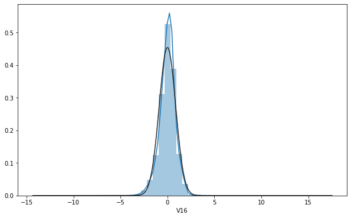

```python
# Dibujamos la distribución
plt.figure(figsize= [10.0, 6.0])
sns.distplot(df["V16"], fit=norm)
```

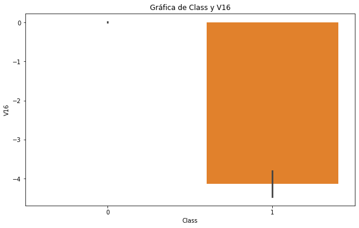

```python
# Dibujamos Class y V16
plt.figure(figsize= [10.0, 6.0])
plt.title("Gráfica de Class y V16")
sns.barplot(x="Class", y="V16", data= df)
plt.show()
```

```python
# calculamos la correlación entre Class y V16
corr_mat = df.corr()
corr_mat.loc["Class", "V16"]
```

```
-0.19653894030401736
```

`V17`

Desconocemos el significado de esta variable por sensibilidad de los datos bancarios.

```python
print("La siguiente variable que vamos a examinar es {0}.".format(df.columns[17]))
```

```
La siguiente variable que vamos a examinar es V17.
```

```python
# Visualizamos los primeros 10 elementos de 'V17'
df["V17"].head(10)
```

```
0    0.207971
1   -0.114805
2    1.109969
3   -0.684093
4   -0.237033
5   -0.058133
6    0.002821
7   -1.222127
8   -0.499768
9   -0.540980
Name: V17, dtype: float64
```

```python
# y los 10 últimos:
df["V17"].tail(10)
```

```
284797   -0.174846
284798    0.939328
284799    0.447184
284800   -0.605252
284801    0.070441
284802    1.991691
284803   -0.025693
284804    0.313502
284805    0.509928
284806   -0.660377
Name: V17, dtype: float64
```

```python
# Vemos el número total de observaciones de V17 y cuántos de esos valores son únicos
print("La variable {0} tiene un total de {1} observaciones y {2} valores únicos.".format(df.columns[17],
                                                                                         df["V17"].count(),
                                                                                         df["V17"].nunique()))
```

```
La variable V17 tiene un total de 284807 observaciones y 275663 valores únicos.
```

```python
# Vemos las estadísticas de V17
df["V17"].describe()
```

```
count    2.848070e+05
mean    -7.466538e-16
std      8.493371e-01
min     -2.516280e+01
25%     -4.837483e-01
50%     -6.567575e-02
75%      3.996750e-01
max      9.253526e+00
Name: V17, dtype: float64
```

```python
# Imprimimos en pantalla algunas de las estadísticas:
print("La variable `V17` tiene:\n un valor mínimo de {0},\
 \n un máximo de {1}, \n una media de {2} \n y una desviación típica de {3}.".format(round(df["V17"].min(),3),
                                                                                   round(df["V17"].max(),3),
                                                                                  round(df["V17"].mean(),3),
                                                                                  round(df["V17"].std(),3)))
```

```
La variable `V17` tiene:
 un valor mínimo de -25.163,
 un máximo de 9.254,
 una media de -0.0
 y una desviación típica de 0.849.
```

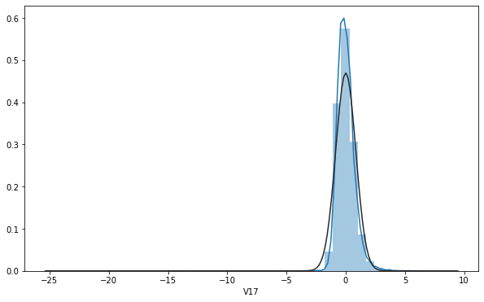

```python
# Dibujamos la distribución
plt.figure(figsize= [10.0, 6.0])
sns.distplot(df["V17"], fit=norm)
```

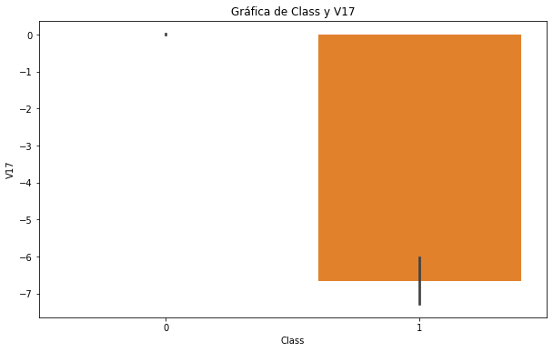

```python
# Dibujamos Class y V17
plt.figure(figsize= [10.0, 6.0])
plt.title("Gráfica de Class y V17")
sns.barplot(x="Class", y="V17", data= df)
plt.show()
```

```python
# calculamos la correlación entre Class y V17
corr_mat = df.corr()
corr_mat.loc["Class", "V17"]
```

```
-0.32648106724371595
```

`V18`

Desconocemos el significado de esta variable por sensibilidad de los datos bancarios.

```python
print("La siguiente variable que vamos a examinar es {0}.".format(df.columns[18]))
```

```
La siguiente variable que vamos a examinar es V18.
```

```python
# Visualizamos los primeros 10 elementos de 'V18'
df["V18"].head(10)
```

```
0    0.025791
1   -0.183361
2   -0.121359
3    1.965775
4   -0.038195
5    0.068653
6   -0.611987
7   -0.358222
8    0.118765
9    0.476677
Name: V18, dtype: float64
```

```python
# y los 10 últimos
df["V18"].tail(10)
```

```
284797   -0.891169
284798   -0.002373
284799    0.388721
284800   -0.163049
284801    0.373110
284802    0.510632
284803   -1.221179
284804    0.395652
284805    1.113981
284806    0.167430
Name: V18, dtype: float64
```

```python
# Vemos el número total de observaciones de V18 y cuántos de esos valores son únicos
print("La variable {0} tiene un total de {1} observaciones y {2} valores únicos.".format(df.columns[18],
                                                                                         df["V18"].count(),
                                                                                         df["V18"].nunique()))
```

```
La variable V18 tiene un total de 284807 observaciones y 275663 valores únicos.
```

```python
# Vemos las estadísticas de V18
df["V18"].describe()
```

```
count    2.848070e+05
mean     4.258754e-16
std      8.381762e-01
min     -9.498746e+00
25%     -4.988498e-01
50%     -3.636312e-03
75%      5.008067e-01
max      5.041069e+00
Name: V18, dtype: float64
```

```python
# Imprimimos en pantalla algunas de las estadísticas:
print("La variable `V18` tiene:\n un valor mínimo de {0},\
 \n un máximo de {1}, \n una media de {2} \n y una desviación típica de {3}.".format(round(df["V18"].min(),3),
                                                                                   round(df["V18"].max(),3),
                                                                                  round(df["V18"].mean(),3),
                                                                                  round(df["V18"].std(),3)))
```

```
La variable `V18` tiene:
 un valor mínimo de -9.499,
 un máximo de 5.041,
 una media de 0.0
 y una desviación típica de 0.838.
```

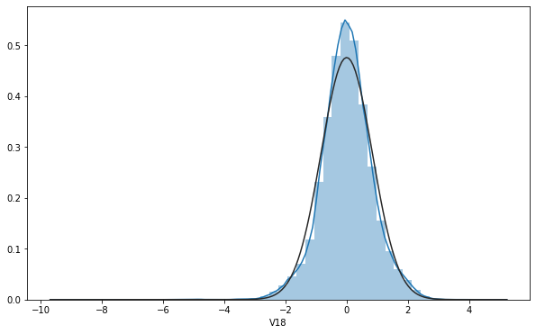

```python
# Dibujamos la distribución
plt.figure(figsize= [10.0, 6.0])
sns.distplot(df["V18"], fit=norm)
```

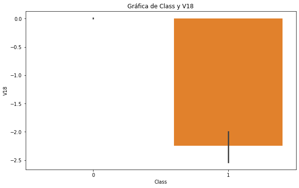

```python
# Dibujamos Class y V18
plt.figure(figsize= [10.0, 6.0])
plt.title("Gráfica de Class y V18")
sns.barplot(x="Class", y="V18", data= df)
plt.show()
```

```python
# calculamos la correlación entre Class y V18
corr_mat = df.corr()
corr_mat.loc["Class", "V18"]
```

```
-0.11148525388904133
```

`V19`

Desconocemos el significado de esta variable por sensibilidad de los datos bancarios.

```python
print("La siguiente variable que vamos a examinar es {0}.".format(df.columns[19]))
```

```
La siguiente variable que vamos a examinar es V19.
```

```python
# Visualizamos los primeros 10 elementos de 'V19'
df["V19"].head(10)
```

```
0    0.403993
1   -0.145783
2   -2.261857
3   -1.232622
4    0.803487
5   -0.033194
6   -0.045575
7    0.324505
8    0.570328
9    0.451773
Name: V19, dtype: float64
```

```python
# los 10 últimos
df["V19"].tail(10)
```

```
284797   -0.290491
284798    2.894952
284799    0.792135
284800    0.561695
284801    0.128904
284802   -0.682920
284803   -1.545556
284804   -0.577252
284805    2.897849
284806   -0.256117
Name: V19, dtype: float64
```

```python
# Vemos el número total de observaciones de V19 y cuántos de esos valores son únicos
print("La variable {0} tiene un total de {1} observaciones y {2} valores únicos.".format(df.columns[19],
                                                                                         df["V19"].count(),
                                                                                         df["V19"].nunique()))
```

```
La variable V19 tiene un total de 284807 observaciones y 275663 valores únicos.
```

```python
# Vemos las estadísticas de V19
df["V19"].describe()
```

```
count    2.848070e+05
mean     9.019919e-16
std      8.140405e-01
min     -7.213527e+00
25%     -4.562989e-01
50%      3.734823e-03
75%      4.589494e-01
max      5.591971e+00
Name: V19, dtype: float64
```

```python
# Imprimimos en pantalla algunas de las estadísticas:
print("La variable `V19` tiene:\n un valor mínimo de {0},\
\n un máximo de {1}, \n una media de {2} \n y una desviación típica de {3}.".format(round(df["V19"].min(),3),
                                                                                   round(df["V19"].max(),3),
                                                                                  round(df["V19"].mean(),3),
                                                                                  round(df["V19"].std(),3)))
```

```
La variable `V19` tiene:
 un valor mínimo de -7.214,
 un máximo de 5.592,
 una media de 0.0
 y una desviación típica de 0.814.
```

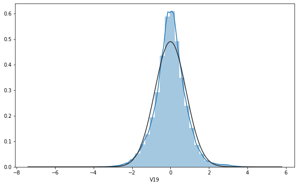

```python
# Dibujamos la distribución
plt.figure(figsize= [10.0, 6.0])
sns.distplot(df["V19"], fit=norm)
```

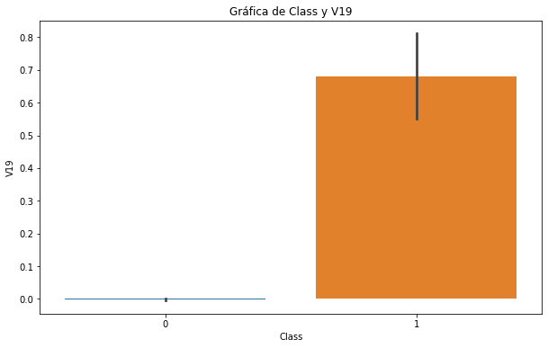

```python
# Dibujamos Class y V19
plt.figure(figsize= [10.0, 6.0])
plt.title("Gráfica de Class y V19")
sns.barplot(x="Class", y="V19", data= df)
plt.show()
```

```python
# calculamos la correlación entre Class y V19
corr_mat = df.corr()
corr_mat.loc["Class", "V19"]
```

```
0.034783013036515056
```

`V20`

Desconocemos el significado de la variable por la sensibilidad de los datos.

```python
print("La siguiente variable que vamos a examinar es {0}.".format(df.columns[20]))
```

```
La siguiente variable que vamos a examinar es V20.
```

```python
# Visualizamos los primeros 10 elementos de 'V20'
df["V20"].head(10)
```

```
0    0.251412
1   -0.069083
2    0.524980
3   -0.208038
4    0.408542
5    0.084968
6   -0.219633
7   -0.156742
8    0.052736
9    0.203711
Name: V20, dtype: float64
```

```python
# los 10 últimos
df["V20"].tail(10)
```

```
284797   -0.139512
284798    0.006666
284799    0.348176
284800   -0.256922
284801    0.000676
284802    1.475829
284803    0.059616
284804    0.001396
284805    0.127434
284806    0.382948
Name: V20, dtype: float64
```

```python
# Vemos el número total de observaciones de V20 y cuántos de esos valores son únicos
print("La variable {0} tiene un total de {1} observaciones y {2} valores únicos.".format(df.columns[20],
                                                                                         df["V20"].count(),
                                                                                         df["V20"].nunique()))
```

```
La variable V20 tiene un total de 284807 observaciones y 275663 valores únicos.
```

```python
# Vemos las estadísticas de V20
df["V20"].describe()
```

```
count    2.848070e+05
mean     5.126845e-16
std      7.709250e-01
min     -5.449772e+01
25%     -2.117214e-01
50%     -6.248109e-02
75%      1.330408e-01
max      3.942090e+01
Name: V20, dtype: float64
```

```python
# Imprimimos en pantalla algunas de las estadísticas:
print("La variable `V20` tiene:\n un valor mínimo de {0},\
\n un máximo de {1}, \n una media de {2} \n y una desviación típica de {3}.".format(round(df["V20"].min(),3),
                                                                                   round(df["V20"].max(),3),
                                                                                  round(df["V20"].mean(),3),
                                                                                  round(df["V20"].std(),3)))
```

```
La variable `V20` tiene:
 un valor mínimo de -54.498,
 un máximo de 39.421,
 una media de 0.0
 y una desviación típica de 0.771.
```

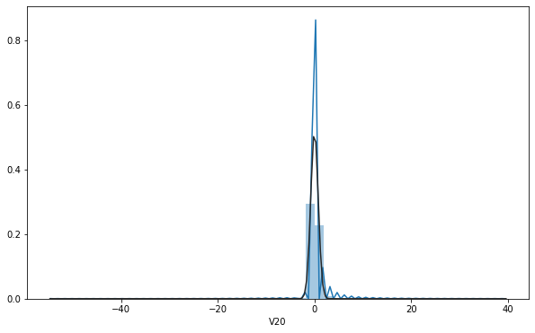

```python
# Dibujamos la distribución
plt.figure(figsize= [10.0, 6.0])
sns.distplot(df["V20"], fit=norm)
```

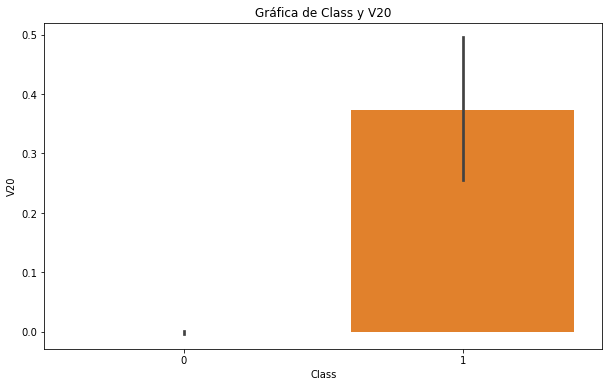

```python
# Dibujamos Class y V19
plt.figure(figsize= [10.0, 6.0])
plt.title("Gráfica de Class y V20")
sns.barplot(x="Class", y="V20", data= df)
plt.show()
```

```python
# calculamos la correlación entre Class y V20
corr_mat = df.corr()
corr_mat.loc["Class", "V20"]
```

```
0.020090324196974638
```

`V21`

Desconocemos el significado de la variable por la sensibilidad de los datos.

```python
print("La siguiente variable que vamos a examinar es {0}.".format(df.columns[21]))
```

```
La siguiente variable que vamos a examinar es V21.
```

```python
# Visualizamos los primeros 10 elementos de 'V21'
df["V21"].head(10)
```

```
0   -0.018307
1   -0.225775
2    0.247998
3   -0.108300
4   -0.009431
5   -0.208254
6   -0.167716
7    1.943465
8   -0.073425
9   -0.246914
Name: V21, dtype: float64
```

```python
# los 10 últimos
df["V21"].tail(10)
```

```
284797   -0.228876
284798    0.099936
284799    0.103302
284800   -0.268048
284801   -0.314205
284802    0.213454
284803    0.214205
284804    0.232045
284805    0.265245
284806    0.261057
Name: V21, dtype: float64
```

```python
# Vemos el número total de observaciones de V21 y cuántos de esos valores son únicos
print("La variable {0} tiene un total de {1} observaciones y {2} valores únicos.".format(df.columns[21],
                                                                                         df["V21"].count(),
                                                                                         df["V21"].nunique()))
```

```
La variable V21 tiene un total de 284807 observaciones y 275663 valores únicos.
```

```python
# Vemos las estadísticas de V21
df["V21"].describe()
```

```
count    2.848070e+05
mean     1.473120e-16
std      7.345240e-01
min     -3.483038e+01
25%     -2.283949e-01
50%     -2.945017e-02
75%      1.863772e-01
max      2.720284e+01
Name: V21, dtype: float64
```

```python
# Imprimimos en pantalla algunas de las estadísticas:
print("La variable `V21` tiene:\n un valor mínimo de {0},\
\n un máximo de {1}, \n una media de {2} \n y una desviación típica de {3}.".format(round(df["V21"].min(),3),
                                                                                   round(df["V21"].max(),3),
                                                                                  round(df["V21"].mean(),3),
                                                                                  round(df["V21"].std(),3)))
```

```
La variable `V21` tiene:
 un valor mínimo de -34.83,
 un máximo de 27.203,
 una media de 0.0
 y una desviación típica de 0.735.
```

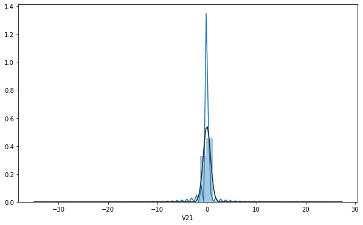

```python
# Dibujamos la distribución
plt.figure(figsize= [10.0, 6.0])
sns.distplot(df["V21"], fit=norm)
```

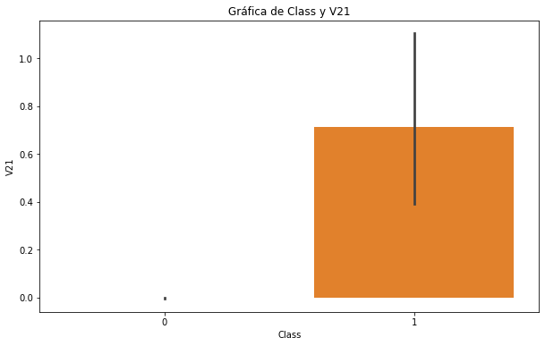

```python
# Dibujamos Class y V21
plt.figure(figsize= [10.0, 6.0])
plt.title("Gráfica de Class y V21")
sns.barplot(x="Class", y="V21", data= df)
plt.show()
```

```python
# calculamos la correlación entre Class y V21
corr_mat = df.corr()
corr_mat.loc["Class", "V21"]
```

```
0.04041338061057565
```

`V22`

Por la sensibilidad de los datos desconocemos el significado de la variable.

```python
print("La siguiente variable que vamos a examinar es {0}.".format(df.columns[22]))
```

```
La siguiente variable que vamos a examinar es V22.
```

```python
# Visualizamos los primeros 10 elementos de 'V22'
df["V22"].head(10)
```

```
0    0.277838
1   -0.638672
2    0.771679
3    0.005274
4    0.798278
5   -0.559825
6   -0.270710
7   -1.015455
8   -0.268092
9   -0.633753
Name: V22, dtype: float64
```

```python
# y también los 10 últimos
df["V22"].tail(10)
```

```
284797   -0.514376
284798    0.337120
284799    0.654850
284800   -0.717211
284801   -0.808520
284802    0.111864
284803    0.924384
284804    0.578229
284805    0.800049
284806    0.643078
Name: V22, dtype: float64
```

```python
# Vemos el número total de observaciones de V22 y cuántos de esos valores son únicos
print("La variable {0} tiene un total de {1} observaciones y {2} valores únicos.".format(df.columns[22],
                                                                                         df["V22"].count(),
                                                                                         df["V22"].nunique()))
```

```
La variable V22 tiene un total de 284807 observaciones y 275663 valores únicos.
```

```python
# Vemos las estadísticas de V22
df["V22"].describe()
```

```
count    2.848070e+05
mean     8.042109e-16
std      7.257016e-01
min     -1.093314e+01
25%     -5.423504e-01
50%      6.781943e-03
75%      5.285536e-01
max      1.050309e+01
Name: V22, dtype: float64
```

```python
# Imprimimos en pantalla algunas de las estadísticas:
print("La variable `V22` tiene:\n un valor mínimo de {0},\
\n un máximo de {1}, \n una media de {2} \n y una desviación típica de {3}.".format(round(df["V22"].min(),3),
                                                                                   round(df["V22"].max(),3),
                                                                                  round(df["V22"].mean(),3),
                                                                                  round(df["V22"].std(),3)))
```

```
La variable `V22` tiene:
 un valor mínimo de -10.933,
 un máximo de 10.503,
 una media de 0.0
 y una desviación típica de 0.726.
```

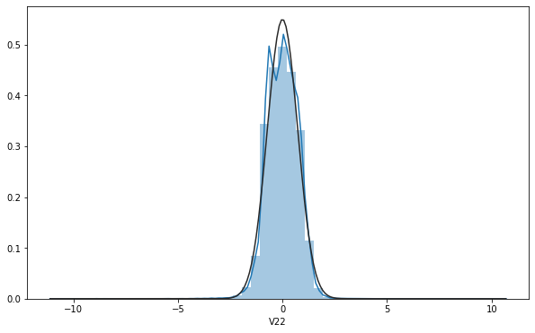

```python
# Dibujamos la distribución
plt.figure(figsize= [10.0, 6.0])
sns.distplot(df["V22"], fit=norm)
```

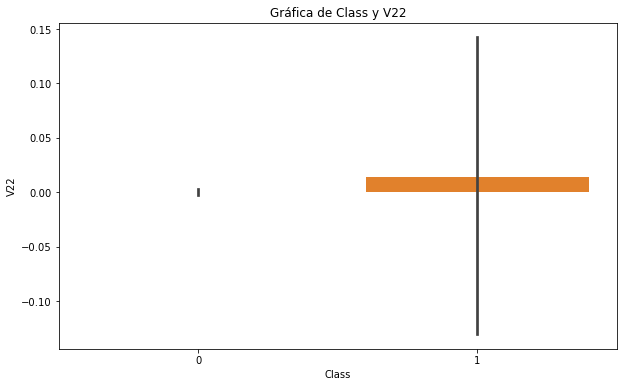

```python
# Dibujamos Class y V22
plt.figure(figsize= [10.0, 6.0])
plt.title("Gráfica de Class y V22")
sns.barplot(x="Class", y="V22", data= df)
plt.show()
```

```python
# calculamos la correlación entre Class y V22
corr_mat = df.corr()
corr_mat.loc["Class", "V22"]
```

```
0.0008053175052983079
```

`V23`

Desconocemos el significado de esta variable debido a la sensibilidad de los datos.

```python
print("La siguiente variable que vamos a examinar es {0}.".format(df.columns[23]))
```

```
La siguiente variable que vamos a examinar es V23.
```

```python
# Visualizamos los primeros 10 elementos de 'V23'
df["V23"].head(10)
```

```
0   -0.110474
1    0.101288
2    0.909412
3   -0.190321
4   -0.137458
5   -0.026398
6   -0.154104
7    0.057504
8   -0.204233
9   -0.120794
Name: V23, dtype: float64
```

```python
# y los 10 últimos
df["V23"].tail(10)
```

```
284797    0.279598
284798    0.251791
284799   -0.348929
284800    0.297930
284801    0.050343
284802    1.014480
284803    0.012463
284804   -0.037501
284805   -0.163298
284806    0.376777
Name: V23, dtype: float64
```

```python
# Vemos el número total de observaciones de V23 y cuántos de esos valores son únicos
print("La variable {0} tiene un total de {1} observaciones y {2} valores únicos.".format(df.columns[23],
                                                                                         df["V23"].count(),
                                                                                         df["V23"].nunique()))
```

```
La variable V23 tiene un total de 284807 observaciones y 275663 valores únicos.
```

```python
# Vemos las estadísticas de V23
df["V23"].describe()
```

```
count    2.848070e+05
mean     5.282512e-16
std      6.244603e-01
min     -4.480774e+01
25%     -1.618463e-01
50%     -1.119293e-02
75%      1.476421e-01
max      2.252841e+01
Name: V23, dtype: float64
```

```python
# Imprimimos en pantalla algunas de las estadísticas:
print("La variable `V23` tiene:\n un valor mínimo de {0},\
\n un máximo de {1}, \n una media de {2} \n y una desviación típica de {3}.".format(round(df["V23"].min(),3),
                                                                                   round(df["V23"].max(),3),
                                                                                  round(df["V23"].mean(),3),
                                                                                  round(df["V23"].std(),3)))
```

```
La variable `V23` tiene:
 un valor mínimo de -44.808,
 un máximo de 22.528,
 una media de 0.0
 y una desviación típica de 0.624.
```

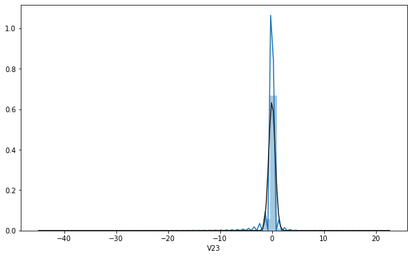

```python
# Dibujamos la distribución
plt.figure(figsize= [10.0, 6.0])
sns.distplot(df["V23"], fit=norm)
```

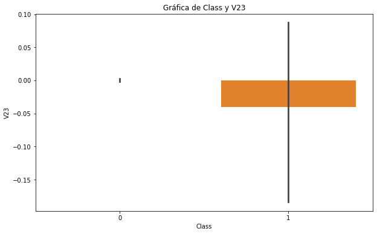

```python
# Dibujamos Class y V23
plt.figure(figsize= [10.0, 6.0])
plt.title("Gráfica de Class y V23")
sns.barplot(x="Class", y="V23", data= df)
plt.show()
```

```python
# calculamos la correlación entre Class y V23
corr_mat = df.corr()
corr_mat.loc["Class", "V23"]
```

```
-0.0026851557402507824
```

`V24`

Desconocemos el significado de esta variable por la sensibilidad de los datos.

```python
print("La siguiente variable que vamos a examinar es {0}.".format(df.columns[24]))
```

```
La siguiente variable que vamos a examinar es V24.
```

```python
# Visualizamos los primeros 10 elementos de 'V24'
df["V24"].head(10)
```

```
0    0.066928
1   -0.339846
2   -0.689281
3   -1.175575
4    0.141267
5   -0.371427
6   -0.780055
7   -0.649709
8    1.011592
9   -0.385050
Name: V24, dtype: float64
```

```python
# y los últimos
df["V24"].tail(10)
```

```
284797    0.371441
284798    0.057688
284799    0.745323
284800   -0.359769
284801    0.102800
284802   -0.509348
284803   -1.016226
284804    0.640134
284805    0.123205
284806    0.008797
Name: V24, dtype: float64
```

```python
# Vemos el número total de observaciones de V24 y cuántos de esos valores son únicos
print("La variable {0} tiene un total de {1} observaciones y {2} valores únicos.".format(df.columns[24],
                                                                                         df["V24"].count(),
                                                                                         df["V24"].nunique()))
```

```
La variable V24 tiene un total de 284807 observaciones y 275663 valores únicos.
```

```python
# Vemos las estadísticas de V24
df["V24"].describe()
```

```
count    2.848070e+05
mean     4.456271e-15
std      6.056471e-01
min     -2.836627e+00
25%     -3.545861e-01
50%      4.097606e-02
75%      4.395266e-01
max      4.584549e+00
Name: V24, dtype: float64
```

```python
# Imprimimos en pantalla algunas de las estadísticas:
print("La variable `V24` tiene:\n un valor mínimo de {0},\
\n un máximo de {1}, \n una media de {2} \n y una desviación típica de {3}.".format(round(df["V24"].min(),3),
                                                                                   round(df["V24"].max(),3),
                                                                                  round(df["V24"].mean(),3),
                                                                                  round(df["V24"].std(),3)))
```

```
La variable `V24` tiene:
 un valor mínimo de -2.837,
 un máximo de 4.585,
 una media de 0.0
 y una desviación típica de 0.606.
```

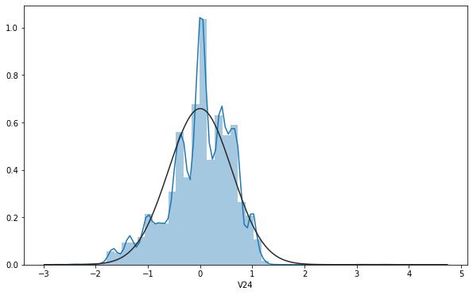

```python
# Dibujamos la distribución
plt.figure(figsize= [10.0, 6.0])
sns.distplot(df["V24"], fit=norm)
```

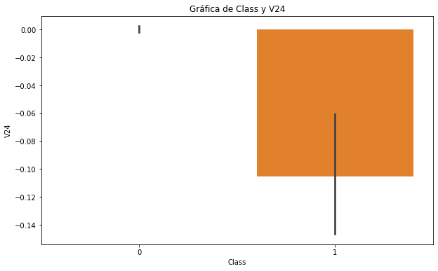

```python
# Dibujamos Class y V24
plt.figure(figsize= [10.0, 6.0])
plt.title("Gráfica de Class y V24")
sns.barplot(x="Class", y="V24", data= df)
plt.show()
```

```python
# calculamos la correlación entre Class y V24
corr_mat = df.corr()
corr_mat.loc["Class", "V24"]
```

```
-0.007220906715952582
```

`V25`

Desconocemos el significado de esta variable por la sensibilidad de los datos.

```python
print("La siguiente variable que vamos a examinar es {0}.".format(df.columns[25]))
```

```
La siguiente variable que vamos a examinar es V25.
```

```python
# Visualizamos los primeros 10 elementos de 'V25'
df["V25"].head(10)
```

```
0    0.128539
1    0.167170
2   -0.327642
3    0.647376
4   -0.206010
5   -0.232794
6    0.750137
7   -0.415267
8    0.373205
9   -0.069733
Name: V25, dtype: float64
```

```python
# los últimos
df["V25"].tail(10)
```

```
284797   -0.559238
284798   -1.508368
284799    0.704545
284800   -0.315610
284801   -0.435870
284802    1.436807
284803   -0.606624
284804    0.265745
284805   -0.569159
284806   -0.473649
Name: V25, dtype: float64
```

```python
# Vemos el número total de observaciones de V25 y cuántos de esos valores son únicos
print("La variable {0} tiene un total de {1} observaciones y {2} valores únicos.".format(df.columns[25],
                                                                                         df["V25"].count(),
                                                                                         df["V25"].nunique()))
```

```
La variable V25 tiene un total de 284807 observaciones y 275663 valores únicos.
```

```python
# Vemos las estadísticas de V25
df["V25"].describe()
```

```
count    2.848070e+05
mean     1.426896e-15
std      5.212781e-01
min     -1.029540e+01
25%     -3.171451e-01
50%      1.659350e-02
75%      3.507156e-01
max      7.519589e+00
Name: V25, dtype: float64
```

```python
# Imprimimos en pantalla algunas de las estadísticas:
print("La variable `V25` tiene:\n un valor mínimo de {0},\
\n un máximo de {1}, \n una media de {2} \n y una desviación típica de {3}.".format(round(df["V25"].min(),3),
                                                                                   round(df["V25"].max(),3),
                                                                                  round(df["V25"].mean(),3),
                                                                                  round(df["V25"].std(),3)))
```

```
La variable `V25` tiene:
 un valor mínimo de -10.295,
 un máximo de 7.52,
 una media de 0.0
 y una desviación típica de 0.521.
```

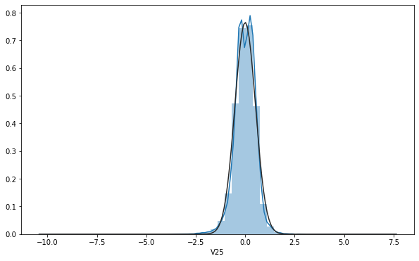

```python
# Dibujamos la distribución
plt.figure(figsize= [10.0, 6.0])
sns.distplot(df["V25"], fit=norm)
```

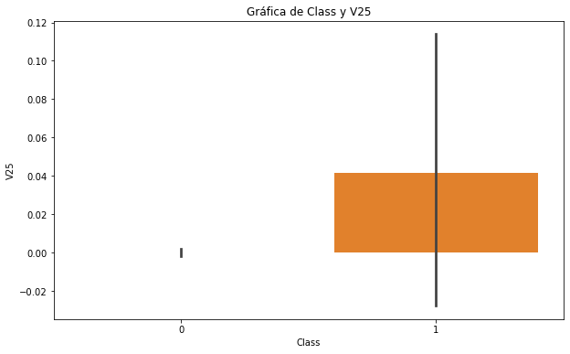

```python
# Dibujamos Class y V25
plt.figure(figsize= [10.0, 6.0])
plt.title("Gráfica de Class y V25")
sns.barplot(x="Class", y="V25", data= df)
plt.show()
```

```python
# calculamos la correlación entre Class y V25
corr_mat = df.corr()
corr_mat.loc["Class", "V25"]
```

```
0.0033077055972996613
```

`V26`

Desconocemos el significado de la variable.

```python
print("La siguiente variable que vamos a examinar es {0}.".format(df.columns[26]))
```

```
La siguiente variable que vamos a examinar es V26.
```

```python
# Visualizamos los primeros 10 elementos de 'V26'
df["V26"].head(10)
```

```
0   -0.189115
1    0.125895
2   -0.139097
3   -0.221929
4    0.502292
5    0.105915
6   -0.257237
7   -0.051634
8   -0.384157
9    0.094199
Name: V26, dtype: float64
```

```python
# y los 10 últimos
df["V26"].tail(10)
```

```
284797    0.113144
284798    0.144023
284799   -0.127579
284800    0.201114
284801    0.124079
284802    0.250034
284803   -0.395255
284804   -0.087371
284805    0.546668
284806   -0.818267
Name: V26, dtype: float64
```

```python
# Vemos el número total de observaciones de V26 y cuántos de esos valores son únicos
print("La variable {0} tiene un total de {1} observaciones y {2} valores únicos.".format(df.columns[26],
                                                                                         df["V26"].count(),
                                                                                         df["V26"].nunique()))
```

```
La variable V26 tiene un total de 284807 observaciones y 275663 valores únicos.
```

```python
# Vemos las estadísticas de V26
df["V26"].describe()
```

```
count    2.848070e+05
mean     1.701640e-15
std      4.822270e-01
min     -2.604551e+00
25%     -3.269839e-01
50%     -5.213911e-02
75%      2.409522e-01
max      3.517346e+00
Name: V26, dtype: float64
```

```python
# Imprimimos en pantalla algunas de las estadísticas:
print("La variable `V26` tiene:\n un valor mínimo de {0},\
\n un máximo de {1}, \n una media de {2} \n y una desviación típica de {3}.".format(round(df["V26"].min(),3),
                                                                                   round(df["V26"].max(),3),
                                                                                  round(df["V26"].mean(),3),
                                                                                  round(df["V26"].std(),3)))
```

```
La variable `V26` tiene:
 un valor mínimo de -2.605,
 un máximo de 3.517,
 una media de 0.0
 y una desviación típica de 0.482.
```

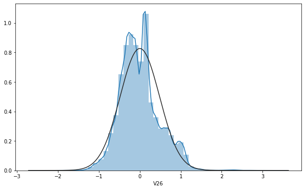

```python
# Dibujamos la distribución
plt.figure(figsize= [10.0, 6.0])
sns.distplot(df["V26"], fit=norm)
```

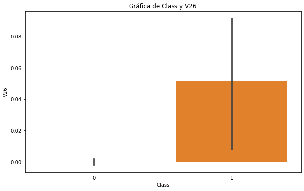

```python
# Dibujamos Class y V26
plt.figure(figsize= [10.0, 6.0])
plt.title("Gráfica de Class y V26")
sns.barplot(x="Class", y="V26", data= df)
plt.show()
```

```python
# calculamos la correlación entre Class y V26
corr_mat = df.corr()
corr_mat.loc["Class", "V26"]
```

```
0.0044553975012833254
```

`V27`

```python
print("La siguiente variable que vamos a examinar es {0}.".format(df.columns[27]))
```

```
La siguiente variable que vamos a examinar es V27.
```

```python
# Visualizamos los primeros 10 elementos de 'V27'
df["V27"].head(10)
```

```
0    0.133558
1   -0.008983
2   -0.055353
3    0.062723
4    0.219422
5    0.253844
6    0.034507
7   -1.206921
8    0.011747
9    0.246219
Name: V27, dtype: float64
```

```python
# y las 10 últimas
df["V27"].tail(10)
```

```
284797    0.131507
284798    0.181205
284799    0.454379
284800   -0.080826
284801    0.217940
284802    0.943651
284803    0.068472
284804    0.004455
284805    0.108821
284806   -0.002415
Name: V27, dtype: float64
```

```python
# Vemos el número total de observaciones de V27 y cuántos de esos valores son únicos
print("La variable {0} tiene un total de {1} observaciones y {2} valores únicos.".format(df.columns[27],
                                                                                         df["V27"].count(),
                                                                                         df["V27"].nunique()))
```

```
La variable V27 tiene un total de 284807 observaciones y 275663 valores únicos.
```

```python
# Vemos las estadísticas de V27
df["V27"].describe()
```

```
count    2.848070e+05
mean    -3.662252e-16
std      4.036325e-01
min     -2.256568e+01
25%     -7.083953e-02
50%      1.342146e-03
75%      9.104512e-02
max      3.161220e+01
Name: V27, dtype: float64
```

```python
# Imprimimos en pantalla algunas de las estadísticas:
print("La variable `V27` tiene:\n un valor mínimo de {0},\
\n un máximo de {1}, \n una media de {2} \n y una desviación típica de {3}.".format(round(df["V27"].min(),3),
                                                                                   round(df["V27"].max(),3),
                                                                                  round(df["V27"].mean(),3),
                                                                                  round(df["V27"].std(),3)))
```

```
La variable `V27` tiene:
 un valor mínimo de -22.566,
 un máximo de 31.612,
 una media de -0.0
 y una desviación típica de 0.404.
```

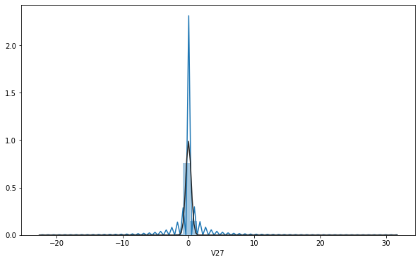

```python
# Dibujamos la distribución
plt.figure(figsize= [10.0, 6.0])
sns.distplot(df["V27"], fit=norm)
```

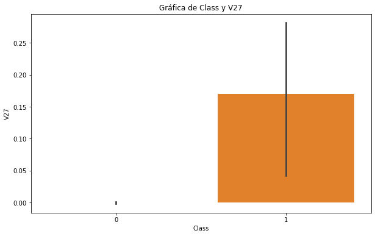

```python
# Dibujamos Class y V27
plt.figure(figsize= [10.0, 6.0])
plt.title("Gráfica de Class y V27")
sns.barplot(x="Class", y="V27", data= df)
plt.show()
```

```python
# calculamos la correlación entre Class y V27
corr_mat = df.corr()
corr_mat.loc["Class", "V27"]
```

```
0.01757972818951348
```

`V28`

Desconocemos el significado de esta variable.

```python
print("La siguiente variable que vamos a examinar es {0}.".format(df.columns[28]))
```

```
La siguiente variable que vamos a examinar es V28.
```

```python
# Visualizamos los primeros 10 elementos de 'V28'
df["V28"].head(10)
```

```
0   -0.021053
1    0.014724
2   -0.059752
3    0.061458
4    0.215153
5    0.081080
6    0.005168
7   -1.085339
8    0.142404
9    0.083076
Name: V28, dtype: float64
```

```python
# y los 10 últimos
df["V28"].tail(10)
```

```
284797    0.081265
284798    0.215243
284799    0.130308
284800   -0.075071
284801    0.068803
284802    0.823731
284803   -0.053527
284804   -0.026561
284805    0.104533
284806    0.013649
Name: V28, dtype: float64
```

```python
# Vemos el número total de observaciones de V28 y cuántos de esos valores son únicos
print("La variable {0} tiene un total de {1} observaciones y {2} valores únicos.".format(df.columns[28],
                                                                                         df["V28"].count(),
                                                                                         df["V28"].nunique()))
```

```
La variable V28 tiene un total de 284807 observaciones y 275663 valores únicos.
```

```python
# Vemos las estadísticas de V28
df["V28"].describe()
```

```
count    2.848070e+05
mean    -1.217809e-16
std      3.300833e-01
min     -1.543008e+01
25%     -5.295979e-02
50%      1.124383e-02
75%      7.827995e-02
max      3.384781e+01
Name: V28, dtype: float64
```

```python
# Imprimimos en pantalla algunas de las estadísticas:
print("La variable `V28` tiene:\n un valor mínimo de {0},\
\n un máximo de {1}, \n una media de {2} \n y una desviación típica de {3}.".format(round(df["V28"].min(),3),
                                                                                   round(df["V28"].max(),3),
                                                                                  round(df["V28"].mean(),3),
                                                                                  round(df["V28"].std(),3)))
```

```
La variable `V28` tiene:
 un valor mínimo de -15.43,
 un máximo de 33.848,
 una media de -0.0
 y una desviación típica de 0.33.
```

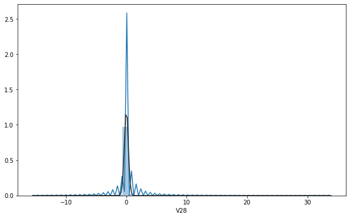

```python
# Dibujamos la distribución
plt.figure(figsize= [10.0, 6.0])
sns.distplot(df["V28"], fit=norm)
```

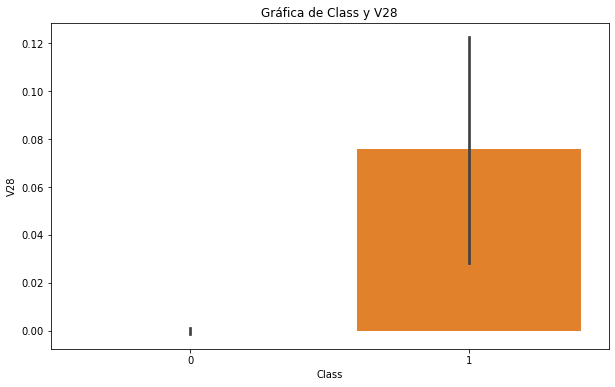

```python
# Dibujamos Class y V28
plt.figure(figsize= [10.0, 6.0])
plt.title("Gráfica de Class y V28")
sns.barplot(x="Class", y="V28", data= df)
plt.show()
```

```python
# calculamos la correlación entre Class y V28
corr_mat = df.corr()
corr_mat.loc["Class", "V28"]
```

```
0.00953604091623609
```

`Amount`

Esta variable mide el importe de la transacción que se ha hecho con la tarjeta de crédito. Es un float dado que se pueden realizar compras con céntimos.

```python
print("La siguiente variable que vamos a examinar es {0}.".format(df.columns[29]))
```

```
La siguiente variable que vamos a examinar es Amount.
```

```python
# Visualizamos los primeros 10 elementos de 'Amount'
df["Amount"].head(10)
```

```
0    149.62
1      2.69
2    378.66
3    123.50
4     69.99
5      3.67
6      4.99
7     40.80
8     93.20
9      3.68
Name: Amount, dtype: float64
```

```python
# y los 10 últimos
df["Amount"].tail(10)
```

```
284797      5.49
284798     24.05
284799     79.99
284800      2.68
284801      2.69
284802      0.77
284803     24.79
284804     67.88
284805     10.00
284806    217.00
Name: Amount, dtype: float64
```

```python
# Vemos el número total de observaciones de Amount y cuántos de esos valores son únicos
print("La variable {0} tiene un total de {1} observaciones y {2} valores únicos.".format(df.columns[29],
                                                                                         df["Amount"].count(),
                                                                                         df["Amount"].nunique()))
```

```
La variable Amount tiene un total de 284807 observaciones y 32767 valores únicos.
```

```python
# Vemos las estadísticas de Amount
df["Amount"].describe()
```

```
count    284807.000000
mean         88.349619
std         250.120109
min           0.000000
25%           5.600000
50%          22.000000
75%          77.165000
max       25691.160000
Name: Amount, dtype: float64
```

```python
# Imprimimos en pantalla algunas de las estadísticas:
print("La variable `Amount` tiene:\n un valor mínimo de {0},\
\n un máximo de {1}, \n una media de {2} \n y una desviación típica de {3}.".format(round(df["Amount"].min(),3),
                                                                                   round(df["Amount"].max(),3),
                                                                                  round(df["Amount"].mean(),3),
                                                                                  round(df["Amount"].std(),3)))
```

```
La variable `Amount` tiene:
 un valor mínimo de 0.0,
 un máximo de 25691.16,
 una media de 88.35
 y una desviación típica de 250.12.
```

La media de las operaciones realizadas con tarjeta es de 88.35, con un máximo de 25691,16 y un mínimo de 0.

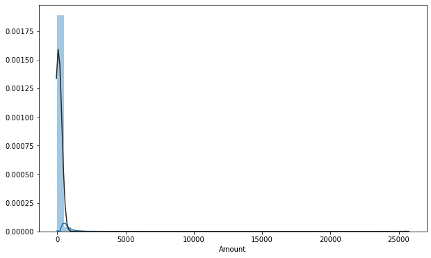

```python
# Dibujamos la distribución
plt.figure(figsize= [10.0, 6.0])
sns.distplot(df["Amount"], fit=norm)
```

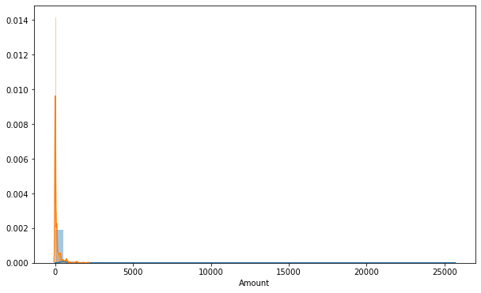

```python
# Vemos la distribución de `Amount` según el valor de `Class`
plt.figure(figsize= [10.0, 6.0])
plt.xlabel("Amount")
sns.distplot(df.Amount[df.Class == 0], label = "No Fraude")
sns.distplot(df.Amount[df.Class == 1], label = "Fraude")
```

Parece que hay más observaciones fraudulentas de cantidades pequeñas. También se observa que hay outliers en Amount, podría ser de alguien que ha comprado un coche con la tarjeta, por ejemplo, pero esas transacciones más elevadas no han sido fraudes.

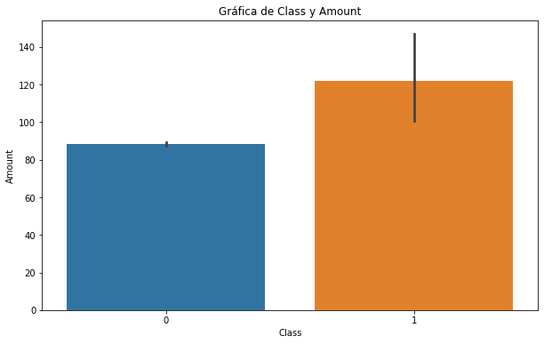

```python
# Dibujamos Class y Amount
plt.figure(figsize= [10.0, 6.0])
plt.title("Gráfica de Class y Amount")
sns.barplot(x="Class", y="Amount", data= df)
plt.show()
```

```python
# calculamos la correlación entre Class y Amount
corr_mat = df.corr()
corr_mat.loc["Class", "Amount"]
```

```
0.005631753006768552
```

`Class`

Class es una variable con dos valores que pueden ser 1, para transacciones fraudulentas, o 0 para no fraudulentas.

```python
print("La última variable que vamos a examinar es {0}.".format(df.columns[30]))
```

```
La última variable que vamos a examinar es Class.
```

```python
# Visualizamos los primeros 10 elementos de 'Class'
df["Class"].head(10)
```

```
0    0
1    0
2    0
3    0
4    0
5    0
6    0
7    0
8    0
9    0
Name: Class, dtype: int64
```

```python
# y los 10 últimos
df["Class"].tail(10)
```

```
284797    0
284798    0
284799    0
284800    0
284801    0
284802    0
284803    0
284804    0
284805    0
284806    0
Name: Class, dtype: int64
```

```python
# Vemos el número total de observaciones de Class y cuántos de esos valores son únicos
print("La variable {0} tiene un total de {1} observaciones y {2} valores únicos.".format(df.columns[30],
                                                                                         df["Class"].count(),
                                                                                         df["Class"].nunique()))
```

```
La variable Class tiene un total de 284807 observaciones y 2 valores únicos.
```

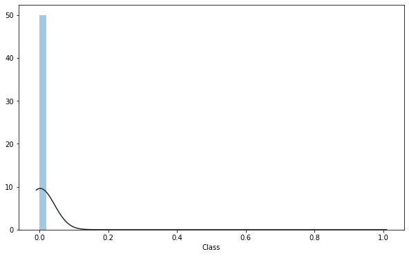

```python
# Dibujamos la distribución
plt.figure(figsize= [10.0, 6.0])
sns.distplot(df["Class"], fit=norm)
```

```python
# Vemos cuántos valores de Class están clasificados como 1 (fraudulentos) y cuantos 0 (no fraudulentos)
df.Class.value_counts()
```

```
0    284315
1       492
Name: Class, dtype: int64
```

```python
# Calculamos los porcentajes de transacciones fraudulentas y no fraudulentas
# definimos los valores
cuenta = df.Class.value_counts()
nofraudulentas = cuenta[0]
fraudulentas = cuenta[1]
porcen_nofrau = (nofraudulentas/df.Class.count())*100
porcen_frau = (fraudulentas/df.Class.count())*100

# imprimimos los porcentajes
print("En nuestro dataset hay {0} transacciones no fraudulentas, un {1:.3f}%, y {2} transacciones fraudulentas, \
 un {3:.3f}% del total.)".format(nofraudulentas,
                                porcen_nofrau,
                                fraudulentas,
                                porcen_frau))
```

```
En nuestro dataset hay 284315 transacciones no fraudulentas, un 99.827%, y 492 transacciones fraudulentas,  un 0.173% del total.)
```

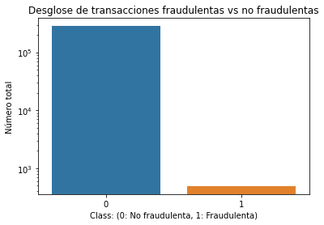

```python
# y lo dibujamos
clase = sns.countplot(x= "Class", data = df)
plt.title("Desglose de transacciones fraudulentas vs no fraudulentas")
plt.xlabel("Class: (0: No fraudulenta, 1: Fraudulenta)")
plt.ylabel("Número total")
clase.set_yscale("log")
```

### **Primeras conclusiones**:

>

> Dadas las características de las variables de la V1 a V28, parece que se haya realizado en ellas un PCA (análisis de componentes principales) para reducir su dimensionalidad.

> Las variables Time y Amount no están escaladas por lo que una opción sería transformarlas.

> Solo un 0.173% de las operaciones es fraudulenta, lo que nos lleva a un problema de datos desbalanceados.